# notebook

```python
# Basic libraries
import numpy as np
import pandas as pd
import matplotlib.pyplot as plt
import matplotlib as mpl
import seaborn as sns
import warnings
import os
import pickle

# SKLEARN Libraries

# Model Selection
from sklearn.model_selection import (
    train_test_split,
    cross_validate,
    cross_val_score,
    GridSearchCV,
    RandomizedSearchCV,
    cross_val_predict,
    learning_curve,
    KFold,
)

from sklearn.metrics import mean_squared_error, make_scorer, r2_score
from sklearn.tree import export_graphviz
from sklearn.tree import plot_tree

# Pipeline
from imblearn.pipeline import Pipeline

# Models
from sklearn.linear_model import LinearRegression
from sklearn.tree import DecisionTreeRegressor
from sklearn.ensemble import RandomForestRegressor, GradientBoostingRegressor, AdaBoostRegressor
from sklearn.linear_model import SGDRegressor
from sklearn.linear_model import ElasticNet
from sklearn.dummy import DummyRegressor
from sklearn.linear_model import Ridge
from sklearn.linear_model import Lasso
from sklearn.svm import SVR



# Preprocessing
from sklearn.compose import ColumnTransformer, TransformedTargetRegressor
from sklearn.preprocessing import FunctionTransformer, StandardScaler, OrdinalEncoder, OneHotEncoder, MinMaxScaler

# Saving models
import pickle
```

```python
import sklearn
print(sklearn.__version__)
```

```
1.2.2
```

```python
random_state = 42
```

First lets read in the multiple csv files from the dataset folder

```python
dirname = os.path.join(os.getcwd(), 'dataset')
datasets = {}
for file in os.listdir(dirname):
    car_brand = file.split('.')[0]
    file_data = pd.DataFrame(pd.read_csv(os.path.join(dirname, file)))
    df = pd.concat([pd.DataFrame([{"brand": car_brand} for i in range(len(file_data))]), file_data], axis=1)
    print(file.split('.')[0])
    display(df)
    datasets[car_brand] = df
```

```
audi
```

|  | brand | model | year | price | transmission | mileage | fuelType | tax | mpg | engineSize |
| --- | --- | --- | --- | --- | --- | --- | --- | --- | --- | --- |
| 0 | audi | A1 | 2017 | 12500 | Manual | 15735 | Petrol | 150 | 55.4 | 1.4 |
| 1 | audi | A6 | 2016 | 16500 | Automatic | 36203 | Diesel | 20 | 64.2 | 2.0 |
| 2 | audi | A1 | 2016 | 11000 | Manual | 29946 | Petrol | 30 | 55.4 | 1.4 |
| 3 | audi | A4 | 2017 | 16800 | Automatic | 25952 | Diesel | 145 | 67.3 | 2.0 |
| 4 | audi | A3 | 2019 | 17300 | Manual | 1998 | Petrol | 145 | 49.6 | 1.0 |
| ... | ... | ... | ... | ... | ... | ... | ... | ... | ... | ... |
| 10663 | audi | A3 | 2020 | 16999 | Manual | 4018 | Petrol | 145 | 49.6 | 1.0 |
| 10664 | audi | A3 | 2020 | 16999 | Manual | 1978 | Petrol | 150 | 49.6 | 1.0 |
| 10665 | audi | A3 | 2020 | 17199 | Manual | 609 | Petrol | 150 | 49.6 | 1.0 |
| 10666 | audi | Q3 | 2017 | 19499 | Automatic | 8646 | Petrol | 150 | 47.9 | 1.4 |
| 10667 | audi | Q3 | 2016 | 15999 | Manual | 11855 | Petrol | 150 | 47.9 | 1.4 |

10668 rows × 10 columns

```
bmw
```

|  | brand | model | year | price | transmission | mileage | fuelType | tax | mpg | engineSize |
| --- | --- | --- | --- | --- | --- | --- | --- | --- | --- | --- |
| 0 | bmw | 5 Series | 2014 | 11200 | Automatic | 67068 | Diesel | 125 | 57.6 | 2.0 |
| 1 | bmw | 6 Series | 2018 | 27000 | Automatic | 14827 | Petrol | 145 | 42.8 | 2.0 |
| 2 | bmw | 5 Series | 2016 | 16000 | Automatic | 62794 | Diesel | 160 | 51.4 | 3.0 |
| 3 | bmw | 1 Series | 2017 | 12750 | Automatic | 26676 | Diesel | 145 | 72.4 | 1.5 |
| 4 | bmw | 7 Series | 2014 | 14500 | Automatic | 39554 | Diesel | 160 | 50.4 | 3.0 |
| ... | ... | ... | ... | ... | ... | ... | ... | ... | ... | ... |
| 10776 | bmw | X3 | 2016 | 19000 | Automatic | 40818 | Diesel | 150 | 54.3 | 2.0 |
| 10777 | bmw | 5 Series | 2016 | 14600 | Automatic | 42947 | Diesel | 125 | 60.1 | 2.0 |
| 10778 | bmw | 3 Series | 2017 | 13100 | Manual | 25468 | Petrol | 200 | 42.8 | 2.0 |
| 10779 | bmw | 1 Series | 2014 | 9930 | Automatic | 45000 | Diesel | 30 | 64.2 | 2.0 |
| 10780 | bmw | X1 | 2017 | 15981 | Automatic | 59432 | Diesel | 125 | 57.6 | 2.0 |

10781 rows × 10 columns

```
cclass
```

|  | brand | model | year | price | transmission | mileage | fuelType | engineSize |
| --- | --- | --- | --- | --- | --- | --- | --- | --- |
| 0 | cclass | C Class | 2020 | 30495 | Automatic | 1200 | Diesel | 2.0 |
| 1 | cclass | C Class | 2020 | 29989 | Automatic | 1000 | Petrol | 1.5 |
| 2 | cclass | C Class | 2020 | 37899 | Automatic | 500 | Diesel | 2.0 |
| 3 | cclass | C Class | 2019 | 30399 | Automatic | 5000 | Diesel | 2.0 |
| 4 | cclass | C Class | 2019 | 29899 | Automatic | 4500 | Diesel | 2.0 |
| ... | ... | ... | ... | ... | ... | ... | ... | ... |
| 3894 | cclass | C Class | 2017 | 14700 | Manual | 31357 | Diesel | 1.6 |
| 3895 | cclass | C Class | 2018 | 18500 | Automatic | 28248 | Diesel | 2.1 |
| 3896 | cclass | C Class | 2014 | 11900 | Manual | 48055 | Diesel | 2.1 |
| 3897 | cclass | C Class | 2014 | 11300 | Automatic | 49865 | Diesel | 2.1 |
| 3898 | cclass | C Class | 2014 | 14800 | Automatic | 55445 | Diesel | 2.1 |

3899 rows × 8 columns

```
focus
```

|  | brand | model | year | price | transmission | mileage | fuelType | engineSize |
| --- | --- | --- | --- | --- | --- | --- | --- | --- |
| 0 | focus | Focus | 2016 | 8000 | Manual | 38852 | Petrol | 1.0 |
| 1 | focus | Focus | 2019 | 13400 | Manual | 11952 | Petrol | 1.0 |
| 2 | focus | Focus | 2019 | 14600 | Manual | 22142 | Petrol | 1.5 |
| 3 | focus | Focus | 2016 | 9450 | Manual | 14549 | Diesel | 1.6 |
| 4 | focus | Focus | 2015 | 9999 | Manual | 7010 | Diesel | 1.6 |
| ... | ... | ... | ... | ... | ... | ... | ... | ... |
| 5449 | focus | Focus | 2019 | 18745 | Manual | 7855 | Diesel | 2.0 |
| 5450 | focus | Focus | 2019 | 16350 | Manual | 13891 | Petrol | 1.0 |
| 5451 | focus | Focus | 2019 | 16850 | Manual | 13452 | Petrol | 1.0 |
| 5452 | focus | Focus | 2019 | 17310 | Automatic | 13376 | Petrol | 1.0 |
| 5453 | focus | Focus | 2019 | 17610 | Automatic | 7886 | Petrol | 1.0 |

5454 rows × 8 columns

```
ford
```

|  | brand | model | year | price | transmission | mileage | fuelType | tax | mpg | engineSize |
| --- | --- | --- | --- | --- | --- | --- | --- | --- | --- | --- |
| 0 | ford | Fiesta | 2017 | 12000 | Automatic | 15944 | Petrol | 150 | 57.7 | 1.0 |
| 1 | ford | Focus | 2018 | 14000 | Manual | 9083 | Petrol | 150 | 57.7 | 1.0 |
| 2 | ford | Focus | 2017 | 13000 | Manual | 12456 | Petrol | 150 | 57.7 | 1.0 |
| 3 | ford | Fiesta | 2019 | 17500 | Manual | 10460 | Petrol | 145 | 40.3 | 1.5 |
| 4 | ford | Fiesta | 2019 | 16500 | Automatic | 1482 | Petrol | 145 | 48.7 | 1.0 |
| ... | ... | ... | ... | ... | ... | ... | ... | ... | ... | ... |
| 17960 | ford | Fiesta | 2016 | 7999 | Manual | 31348 | Petrol | 125 | 54.3 | 1.2 |
| 17961 | ford | B-MAX | 2017 | 8999 | Manual | 16700 | Petrol | 150 | 47.1 | 1.4 |
| 17962 | ford | B-MAX | 2014 | 7499 | Manual | 40700 | Petrol | 30 | 57.7 | 1.0 |
| 17963 | ford | Focus | 2015 | 9999 | Manual | 7010 | Diesel | 20 | 67.3 | 1.6 |
| 17964 | ford | KA | 2018 | 8299 | Manual | 5007 | Petrol | 145 | 57.7 | 1.2 |

17965 rows × 10 columns

```
hyundi
```

|  | brand | model | year | price | transmission | mileage | fuelType | tax(£) | mpg | engineSize |
| --- | --- | --- | --- | --- | --- | --- | --- | --- | --- | --- |
| 0 | hyundi | I20 | 2017 | 7999 | Manual | 17307 | Petrol | 145 | 58.9 | 1.2 |
| 1 | hyundi | Tucson | 2016 | 14499 | Automatic | 25233 | Diesel | 235 | 43.5 | 2.0 |
| 2 | hyundi | Tucson | 2016 | 11399 | Manual | 37877 | Diesel | 30 | 61.7 | 1.7 |
| 3 | hyundi | I10 | 2016 | 6499 | Manual | 23789 | Petrol | 20 | 60.1 | 1.0 |
| 4 | hyundi | IX35 | 2015 | 10199 | Manual | 33177 | Diesel | 160 | 51.4 | 2.0 |
| ... | ... | ... | ... | ... | ... | ... | ... | ... | ... | ... |
| 4855 | hyundi | I30 | 2016 | 8680 | Manual | 25906 | Diesel | 0 | 78.4 | 1.6 |
| 4856 | hyundi | I40 | 2015 | 7830 | Manual | 59508 | Diesel | 30 | 65.7 | 1.7 |
| 4857 | hyundi | I10 | 2017 | 6830 | Manual | 13810 | Petrol | 20 | 60.1 | 1.0 |
| 4858 | hyundi | Tucson | 2018 | 13994 | Manual | 23313 | Petrol | 145 | 44.8 | 1.6 |
| 4859 | hyundi | Tucson | 2016 | 15999 | Automatic | 11472 | Diesel | 125 | 57.6 | 1.7 |

4860 rows × 10 columns

```
merc
```

|  | brand | model | year | price | transmission | mileage | fuelType | tax | mpg | engineSize |
| --- | --- | --- | --- | --- | --- | --- | --- | --- | --- | --- |
| 0 | merc | SLK | 2005 | 5200 | Automatic | 63000 | Petrol | 325 | 32.1 | 1.8 |
| 1 | merc | S Class | 2017 | 34948 | Automatic | 27000 | Hybrid | 20 | 61.4 | 2.1 |
| 2 | merc | SL CLASS | 2016 | 49948 | Automatic | 6200 | Petrol | 555 | 28.0 | 5.5 |
| 3 | merc | G Class | 2016 | 61948 | Automatic | 16000 | Petrol | 325 | 30.4 | 4.0 |
| 4 | merc | G Class | 2016 | 73948 | Automatic | 4000 | Petrol | 325 | 30.1 | 4.0 |
| ... | ... | ... | ... | ... | ... | ... | ... | ... | ... | ... |
| 13114 | merc | C Class | 2020 | 35999 | Automatic | 500 | Diesel | 145 | 55.4 | 2.0 |
| 13115 | merc | B Class | 2020 | 24699 | Automatic | 2500 | Diesel | 145 | 55.4 | 2.0 |
| 13116 | merc | GLC Class | 2019 | 30999 | Automatic | 11612 | Diesel | 145 | 41.5 | 2.1 |
| 13117 | merc | CLS Class | 2019 | 37990 | Automatic | 2426 | Diesel | 145 | 45.6 | 2.0 |
| 13118 | merc | S Class | 2019 | 54999 | Automatic | 2075 | Diesel | 145 | 52.3 | 2.9 |

13119 rows × 10 columns

```
skoda
```

|  | brand | model | year | price | transmission | mileage | fuelType | tax | mpg | engineSize |
| --- | --- | --- | --- | --- | --- | --- | --- | --- | --- | --- |
| 0 | skoda | Octavia | 2017 | 10550 | Manual | 25250 | Petrol | 150 | 54.3 | 1.4 |
| 1 | skoda | Citigo | 2018 | 8200 | Manual | 1264 | Petrol | 145 | 67.3 | 1.0 |
| 2 | skoda | Octavia | 2019 | 15650 | Automatic | 6825 | Diesel | 145 | 67.3 | 2.0 |
| 3 | skoda | Yeti Outdoor | 2015 | 14000 | Automatic | 28431 | Diesel | 165 | 51.4 | 2.0 |
| 4 | skoda | Superb | 2019 | 18350 | Manual | 10912 | Petrol | 150 | 40.9 | 1.5 |
| ... | ... | ... | ... | ... | ... | ... | ... | ... | ... | ... |
| 6262 | skoda | Yeti | 2014 | 11440 | Semi-Auto | 14569 | Petrol | 160 | 44.8 | 1.2 |
| 6263 | skoda | Octavia | 2014 | 10990 | Semi-Auto | 49999 | Petrol | 30 | 56.5 | 1.4 |
| 6264 | skoda | Fabia | 2017 | 9500 | Semi-Auto | 17131 | Petrol | 145 | 61.4 | 1.0 |
| 6265 | skoda | Citigo | 2016 | 5999 | Manual | 21747 | Petrol | 20 | 62.8 | 1.0 |
| 6266 | skoda | Fabia | 2017 | 9232 | Semi-Auto | 42530 | Petrol | 20 | 60.1 | 1.2 |

6267 rows × 10 columns

```
toyota
```

|  | brand | model | year | price | transmission | mileage | fuelType | tax | mpg | engineSize |
| --- | --- | --- | --- | --- | --- | --- | --- | --- | --- | --- |
| 0 | toyota | GT86 | 2016 | 16000 | Manual | 24089 | Petrol | 265 | 36.2 | 2.0 |
| 1 | toyota | GT86 | 2017 | 15995 | Manual | 18615 | Petrol | 145 | 36.2 | 2.0 |
| 2 | toyota | GT86 | 2015 | 13998 | Manual | 27469 | Petrol | 265 | 36.2 | 2.0 |
| 3 | toyota | GT86 | 2017 | 18998 | Manual | 14736 | Petrol | 150 | 36.2 | 2.0 |
| 4 | toyota | GT86 | 2017 | 17498 | Manual | 36284 | Petrol | 145 | 36.2 | 2.0 |
| ... | ... | ... | ... | ... | ... | ... | ... | ... | ... | ... |
| 6733 | toyota | IQ | 2011 | 5500 | Automatic | 30000 | Petrol | 20 | 58.9 | 1.0 |
| 6734 | toyota | Urban Cruiser | 2011 | 4985 | Manual | 36154 | Petrol | 125 | 50.4 | 1.3 |
| 6735 | toyota | Urban Cruiser | 2012 | 4995 | Manual | 46000 | Diesel | 125 | 57.6 | 1.4 |
| 6736 | toyota | Urban Cruiser | 2011 | 3995 | Manual | 60700 | Petrol | 125 | 50.4 | 1.3 |
| 6737 | toyota | Urban Cruiser | 2011 | 4495 | Manual | 45128 | Petrol | 125 | 50.4 | 1.3 |

6738 rows × 10 columns

```
vauxhall
```

|  | brand | model | year | price | transmission | mileage | fuelType | tax | mpg | engineSize |
| --- | --- | --- | --- | --- | --- | --- | --- | --- | --- | --- |
| 0 | vauxhall | Corsa | 2018 | 7885 | Manual | 9876 | Petrol | 145 | 55.4 | 1.4 |
| 1 | vauxhall | Corsa | 2019 | 11995 | Manual | 2500 | Petrol | 145 | 54.3 | 1.4 |
| 2 | vauxhall | Corsa | 2017 | 9777 | Automatic | 9625 | Petrol | 145 | 47.9 | 1.4 |
| 3 | vauxhall | Corsa | 2016 | 8500 | Manual | 25796 | Petrol | 30 | 55.4 | 1.4 |
| 4 | vauxhall | Corsa | 2019 | 10000 | Manual | 3887 | Petrol | 145 | 43.5 | 1.4 |
| ... | ... | ... | ... | ... | ... | ... | ... | ... | ... | ... |
| 13627 | vauxhall | Tigra | 2007 | 2499 | Manual | 48640 | Petrol | 165 | 46.3 | 1.4 |
| 13628 | vauxhall | Vectra | 2007 | 1795 | Manual | 75000 | Petrol | 240 | 39.2 | 1.8 |
| 13629 | vauxhall | Vectra | 2005 | 1495 | Manual | 74000 | Petrol | 235 | 38.7 | 1.8 |
| 13630 | vauxhall | Vectra | 2008 | 1695 | Automatic | 131000 | Diesel | 200 | 39.8 | 1.9 |
| 13631 | vauxhall | Vectra | 2005 | 1450 | Manual | 147000 | Petrol | 330 | 27.9 | 3.2 |

13632 rows × 10 columns

```
vw
```

|  | brand | model | year | price | transmission | mileage | fuelType | tax | mpg | engineSize |
| --- | --- | --- | --- | --- | --- | --- | --- | --- | --- | --- |
| 0 | vw | T-Roc | 2019 | 25000 | Automatic | 13904 | Diesel | 145 | 49.6 | 2.0 |
| 1 | vw | T-Roc | 2019 | 26883 | Automatic | 4562 | Diesel | 145 | 49.6 | 2.0 |
| 2 | vw | T-Roc | 2019 | 20000 | Manual | 7414 | Diesel | 145 | 50.4 | 2.0 |
| 3 | vw | T-Roc | 2019 | 33492 | Automatic | 4825 | Petrol | 145 | 32.5 | 2.0 |
| 4 | vw | T-Roc | 2019 | 22900 | Semi-Auto | 6500 | Petrol | 150 | 39.8 | 1.5 |
| ... | ... | ... | ... | ... | ... | ... | ... | ... | ... | ... |
| 15152 | vw | Eos | 2012 | 5990 | Manual | 74000 | Diesel | 125 | 58.9 | 2.0 |
| 15153 | vw | Fox | 2008 | 1799 | Manual | 88102 | Petrol | 145 | 46.3 | 1.2 |
| 15154 | vw | Fox | 2009 | 1590 | Manual | 70000 | Petrol | 200 | 42.0 | 1.4 |
| 15155 | vw | Fox | 2006 | 1250 | Manual | 82704 | Petrol | 150 | 46.3 | 1.2 |
| 15156 | vw | Fox | 2007 | 2295 | Manual | 74000 | Petrol | 145 | 46.3 | 1.2 |

15157 rows × 10 columns

Since Focus and C Class arent car brands like the rest of the dataset but rather model types, we will have to first change its type accordingly (Ford Focus and Medcedes C Class). Both of these datasets also lack the tax and miles per gallon since they were scraped from an older source according to the owner of the dataset

```python
datasets['cclass']['brand'] = 'merc'
datasets['focus']['brand'] = 'ford'

# Add the missing tax and mpg columns into ford Focus
datasets['cclass'].loc[:, ['tax', 'mpg']] = None
datasets['focus'].loc[:, ['tax', 'mpg']] = None
display(datasets['focus'])
```

|  | brand | model | year | price | transmission | mileage | fuelType | engineSize | tax | mpg |
| --- | --- | --- | --- | --- | --- | --- | --- | --- | --- | --- |
| 0 | ford | Focus | 2016 | 8000 | Manual | 38852 | Petrol | 1.0 | None | None |
| 1 | ford | Focus | 2019 | 13400 | Manual | 11952 | Petrol | 1.0 | None | None |
| 2 | ford | Focus | 2019 | 14600 | Manual | 22142 | Petrol | 1.5 | None | None |
| 3 | ford | Focus | 2016 | 9450 | Manual | 14549 | Diesel | 1.6 | None | None |
| 4 | ford | Focus | 2015 | 9999 | Manual | 7010 | Diesel | 1.6 | None | None |
| ... | ... | ... | ... | ... | ... | ... | ... | ... | ... | ... |
| 5449 | ford | Focus | 2019 | 18745 | Manual | 7855 | Diesel | 2.0 | None | None |
| 5450 | ford | Focus | 2019 | 16350 | Manual | 13891 | Petrol | 1.0 | None | None |
| 5451 | ford | Focus | 2019 | 16850 | Manual | 13452 | Petrol | 1.0 | None | None |
| 5452 | ford | Focus | 2019 | 17310 | Automatic | 13376 | Petrol | 1.0 | None | None |
| 5453 | ford | Focus | 2019 | 17610 | Automatic | 7886 | Petrol | 1.0 | None | None |

5454 rows × 10 columns

Rename the tax column in the hyundi dataset to make it consistent with other Car Brands

```python
datasets['hyundi'].rename(columns={'tax(£)': 'tax'}, inplace=True)
display(datasets['hyundi'])
```

|  | brand | model | year | price | transmission | mileage | fuelType | tax | mpg | engineSize |
| --- | --- | --- | --- | --- | --- | --- | --- | --- | --- | --- |
| 0 | hyundi | I20 | 2017 | 7999 | Manual | 17307 | Petrol | 145 | 58.9 | 1.2 |
| 1 | hyundi | Tucson | 2016 | 14499 | Automatic | 25233 | Diesel | 235 | 43.5 | 2.0 |
| 2 | hyundi | Tucson | 2016 | 11399 | Manual | 37877 | Diesel | 30 | 61.7 | 1.7 |
| 3 | hyundi | I10 | 2016 | 6499 | Manual | 23789 | Petrol | 20 | 60.1 | 1.0 |
| 4 | hyundi | IX35 | 2015 | 10199 | Manual | 33177 | Diesel | 160 | 51.4 | 2.0 |
| ... | ... | ... | ... | ... | ... | ... | ... | ... | ... | ... |
| 4855 | hyundi | I30 | 2016 | 8680 | Manual | 25906 | Diesel | 0 | 78.4 | 1.6 |
| 4856 | hyundi | I40 | 2015 | 7830 | Manual | 59508 | Diesel | 30 | 65.7 | 1.7 |
| 4857 | hyundi | I10 | 2017 | 6830 | Manual | 13810 | Petrol | 20 | 60.1 | 1.0 |
| 4858 | hyundi | Tucson | 2018 | 13994 | Manual | 23313 | Petrol | 145 | 44.8 | 1.6 |
| 4859 | hyundi | Tucson | 2016 | 15999 | Automatic | 11472 | Diesel | 125 | 57.6 | 1.7 |

4860 rows × 10 columns

Now using the values from the Ford and Merc datasets, we can use them to impute the tax and mpg columns from the Focus and C Class datasets

First get a general overview

```python
display(datasets['ford'][datasets['ford']['model'] == ' Focus'][['tax', 'mpg']].describe())
display(datasets['merc'][datasets['merc']['model'] == ' C Class'][['tax', 'mpg']].describe())
```

|  | tax | mpg |
| --- | --- | --- |
| count | 4588.000000 | 4588.000000 |
| mean | 111.156277 | 60.089385 |
| std | 63.634199 | 10.733369 |
| min | 0.000000 | 26.300000 |
| 25% | 20.000000 | 55.400000 |
| 50% | 145.000000 | 60.100000 |
| 75% | 145.000000 | 67.300000 |
| max | 330.000000 | 83.100000 |

|  | tax | mpg |
| --- | --- | --- |
| count | 3747.000000 | 3747.000000 |
| mean | 118.405391 | 56.883133 |
| std | 63.088864 | 16.371416 |
| min | 0.000000 | 23.000000 |
| 25% | 125.000000 | 46.300000 |
| 50% | 145.000000 | 57.700000 |
| 75% | 145.000000 | 64.200000 |
| max | 580.000000 | 217.300000 |

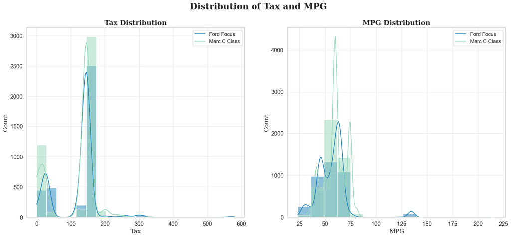

```python
sns.set_context('notebook',  font_scale=1.2)
sns.set_style('whitegrid', {'grid.color': '0.9'})

combined_df =  pd.concat([datasets['ford'], datasets['merc']], axis=0)
# Drop all whose model is neither focus nor cclass
combined_df = combined_df[combined_df['model'].isin([' Focus', ' C Class'])]

fig, ax = plt.subplots(1, 2, figsize=(20, 8))
plt.suptitle("Distribution of Tax and MPG", fontfamily='serif', fontweight='bold', fontsize=20)

sns.histplot(data=combined_df, x='tax', ax=ax[0], kde=True, palette='YlGnBu', hue='model', bins=20)

ax[0].set_title("Tax Distribution", fontfamily='serif',fontweight='bold', fontsize=16)
ax[0].set_xlabel('Tax', fontfamily='serif', fontsize=14)
ax[0].set_ylabel('Count', fontfamily='serif', fontsize=14)
ax[0].legend(labels=['Ford Focus', 'Merc C Class'], loc='upper right', fontsize=12)


sns.histplot(data=combined_df, x='mpg', ax=ax[1], kde=True, palette='YlGnBu', hue='model', bins=15)

ax[1].set_title("MPG Distribution", fontfamily='serif',fontweight='bold', fontsize=16)
ax[1].set_xlabel('MPG', fontfamily='serif', fontsize=14)
ax[1].set_ylabel('Count', fontfamily='serif', fontsize=14)
ax[1].legend(labels=['Ford Focus', 'Merc C Class'], loc='upper right', fontsize=12)

plt.show()
```

**Observations**:

- From the graph, it seems that the Tax distribution have a similar distribution for Ford Focus and Merc C Class with both having a bimodal distribution
- The distribution for Miles Per Gallon are not as similar but they both seem to have a consistent mode at around 60
- From the histogram of the tax and MPG distribution, it seems safe to impute the missing values of tax and MPG with the median

Imputation using median

```python
c_class_tax_median = datasets['merc'][datasets['merc']['model'] == ' C Class']['tax'].median()
focus_tax_median = datasets['ford'][datasets['ford']['model'] == ' Focus']['tax'].median()

c_class_mpg_median = datasets['merc'][datasets['merc']['model'] == ' C Class']['mpg'].median()
focus_mpg_median = datasets['ford'][datasets['ford']['model'] == ' Focus']['mpg'].median()


datasets['cclass'].loc[:, ['tax', 'mpg']] = [c_class_tax_median, c_class_mpg_median]
datasets['focus'].loc[:, ['tax', 'mpg']] = [focus_tax_median, focus_mpg_median]

datasets['cclass']['brand'] = 'merc'
datasets['focus']['brand'] = 'ford'
```

```python
display(datasets['focus'].head())
display(datasets['cclass'].head())
```

|  | brand | model | year | price | transmission | mileage | fuelType | engineSize | tax | mpg |
| --- | --- | --- | --- | --- | --- | --- | --- | --- | --- | --- |
| 0 | ford | Focus | 2016 | 8000 | Manual | 38852 | Petrol | 1.0 | 145.0 | 60.1 |
| 1 | ford | Focus | 2019 | 13400 | Manual | 11952 | Petrol | 1.0 | 145.0 | 60.1 |
| 2 | ford | Focus | 2019 | 14600 | Manual | 22142 | Petrol | 1.5 | 145.0 | 60.1 |
| 3 | ford | Focus | 2016 | 9450 | Manual | 14549 | Diesel | 1.6 | 145.0 | 60.1 |
| 4 | ford | Focus | 2015 | 9999 | Manual | 7010 | Diesel | 1.6 | 145.0 | 60.1 |

|  | brand | model | year | price | transmission | mileage | fuelType | engineSize | tax | mpg |
| --- | --- | --- | --- | --- | --- | --- | --- | --- | --- | --- |
| 0 | merc | C Class | 2020 | 30495 | Automatic | 1200 | Diesel | 2.0 | 145.0 | 57.7 |
| 1 | merc | C Class | 2020 | 29989 | Automatic | 1000 | Petrol | 1.5 | 145.0 | 57.7 |
| 2 | merc | C Class | 2020 | 37899 | Automatic | 500 | Diesel | 2.0 | 145.0 | 57.7 |
| 3 | merc | C Class | 2019 | 30399 | Automatic | 5000 | Diesel | 2.0 | 145.0 | 57.7 |
| 4 | merc | C Class | 2019 | 29899 | Automatic | 4500 | Diesel | 2.0 | 145.0 | 57.7 |

With all the data cleaned, we can now join all the datasets together into one

```python
df = pd.concat(datasets.values())
display(df)
```

|  | brand | model | year | price | transmission | mileage | fuelType | tax | mpg | engineSize |
| --- | --- | --- | --- | --- | --- | --- | --- | --- | --- | --- |
| 0 | audi | A1 | 2017 | 12500 | Manual | 15735 | Petrol | 150.0 | 55.4 | 1.4 |
| 1 | audi | A6 | 2016 | 16500 | Automatic | 36203 | Diesel | 20.0 | 64.2 | 2.0 |
| 2 | audi | A1 | 2016 | 11000 | Manual | 29946 | Petrol | 30.0 | 55.4 | 1.4 |
| 3 | audi | A4 | 2017 | 16800 | Automatic | 25952 | Diesel | 145.0 | 67.3 | 2.0 |
| 4 | audi | A3 | 2019 | 17300 | Manual | 1998 | Petrol | 145.0 | 49.6 | 1.0 |
| ... | ... | ... | ... | ... | ... | ... | ... | ... | ... | ... |
| 15152 | vw | Eos | 2012 | 5990 | Manual | 74000 | Diesel | 125.0 | 58.9 | 2.0 |
| 15153 | vw | Fox | 2008 | 1799 | Manual | 88102 | Petrol | 145.0 | 46.3 | 1.2 |
| 15154 | vw | Fox | 2009 | 1590 | Manual | 70000 | Petrol | 200.0 | 42.0 | 1.4 |
| 15155 | vw | Fox | 2006 | 1250 | Manual | 82704 | Petrol | 150.0 | 46.3 | 1.2 |
| 15156 | vw | Fox | 2007 | 2295 | Manual | 74000 | Petrol | 145.0 | 46.3 | 1.2 |

108540 rows × 10 columns

### 1. EDA

```python
print(list(df.columns))
```

```
['brand', 'model', 'year', 'price', 'transmission', 'mileage', 'fuelType', 'tax', 'mpg', 'engineSize']
```

```python
print(f"Shape: {df.shape}")
print(df.info())
```

```
Shape: (108540, 10)
<class 'pandas.core.frame.DataFrame'>
Int64Index: 108540 entries, 0 to 15156
Data columns (total 10 columns):
 #   Column        Non-Null Count   Dtype
---  ------        --------------   -----
 0   brand         108540 non-null  object
 1   model         108540 non-null  object
 2   year          108540 non-null  int64
 3   price         108540 non-null  int64
 4   transmission  108540 non-null  object
 5   mileage       108540 non-null  int64
 6   fuelType      108540 non-null  object
 7   tax           108540 non-null  float64
 8   mpg           108540 non-null  float64
 9   engineSize    108540 non-null  float64
dtypes: float64(3), int64(3), object(4)
memory usage: 9.1+ MB
None
```

**Data Dictionary**

| Column Name | Data Type | Definition |
| --- | --- | --- |
| Brand | Nominal Category | Manufacturer of the car |
| Model | Nominal Category | Model of the Car |
| Year | Numeric | Car Registration Year |
| Transmission | Ordinal Category | Type of Gearbox |
| Mileage | Numeric | Distance Used |
| FuelType | Nominal Category | Engine Fuel Type |
| Tax | Numeric | Road Tax |
| MPG | Numeric | Miles Per Gallon |
| EngineSize | Numeric | Engine Size in litres |
| Price | Target Variable | Price of the car in Great Britain Pound |

Now let's get a description of the data

```python
print("SUMMARY STATISTICS OF NUMERIC COLUMNS")
display(df.describe().T)
```

```
SUMMARY STATISTICS OF NUMERIC COLUMNS
```

|  | count | mean | std | min | 25% | 50% | 75% | max |
| --- | --- | --- | --- | --- | --- | --- | --- | --- |
| year | 108540.0 | 2017.098028 | 2.130057 | 1970.0 | 2016.00 | 2017.0 | 2019.0 | 2060.0 |
| price | 108540.0 | 16890.124046 | 9756.266820 | 450.0 | 10229.50 | 14698.0 | 20940.0 | 159999.0 |
| mileage | 108540.0 | 23025.928469 | 21176.423684 | 1.0 | 7491.75 | 17265.0 | 32236.0 | 323000.0 |
| tax | 108540.0 | 122.428275 | 60.765335 | 0.0 | 125.00 | 145.0 | 145.0 | 580.0 |
| mpg | 108540.0 | 55.505709 | 15.470838 | 0.3 | 47.10 | 56.5 | 61.4 | 470.8 |
| engineSize | 108540.0 | 1.661644 | 0.557058 | 0.0 | 1.20 | 1.6 | 2.0 | 6.6 |

**Observations**:

- From year, it seems that there contains data in the year 2060. However, this does not make sense

```python
# Get all unique years from the dataset
print(np.sort(df['year'].unique()))
```

```
[1970 1991 1995 1996 1997 1998 1999 2000 2001 2002 2003 2004 2005 2006
 2007 2008 2009 2010 2011 2012 2013 2014 2015 2016 2017 2018 2019 2020
 2060]
```

From the dataset, it seems that the only year that does not make sense is 2060

```python
display(df[df['year'] == 2060])
```

|  | brand | model | year | price | transmission | mileage | fuelType | tax | mpg | engineSize |
| --- | --- | --- | --- | --- | --- | --- | --- | --- | --- | --- |
| 17726 | ford | Fiesta | 2060 | 6495 | Automatic | 54807 | Petrol | 205.0 | 42.8 | 1.4 |

There is only one record with the year 2060 suggesting that it is likely a typo. However, since there is no way to get back the original year for the record, we would be better off deleting it

```python
df.drop(df[df['year'] == 2060].index, inplace=True)
print(np.sort(df['year'].unique()))
```

```
[1970 1991 1995 1996 1997 1998 1999 2000 2001 2002 2003 2004 2005 2006
 2007 2008 2009 2010 2011 2012 2013 2014 2015 2016 2017 2018 2019 2020]
```

Next lets check the dataset for any missing values or duplicate records

```python
print("MISSING VALUES:")
print(df.isnull().sum())
print('\n')
print("NUMBER OF DUPLICATES: ", df.duplicated(keep='first').sum())
```

```
MISSING VALUES:
brand           0
model           0
year            0
price           0
transmission    0
mileage         0
fuelType        0
tax             0
mpg             0
engineSize      0
dtype: int64


NUMBER OF DUPLICATES:  3061
```

From the dataset, it seems that there is no missing values but there contains 3061 duplicate records. As such, let's delete the duplicate records from the dataset

```python
# Delete duplicates
df.drop_duplicates(keep='first', inplace=True)
print("NUMBER OF DUPLICATES: ", df.duplicated(keep='first').sum())
```

```
NUMBER OF DUPLICATES:  0
```

Let us convert all the categorical variables into the type category

```python
df[['brand', 'model', 'transmission', 'fuelType']] = df[['brand', 'model', 'transmission', 'fuelType']].astype('category')
print(df.info())
```

```
<class 'pandas.core.frame.DataFrame'>
Int64Index: 105478 entries, 0 to 15156
Data columns (total 10 columns):
 #   Column        Non-Null Count   Dtype
---  ------        --------------   -----
 0   brand         105478 non-null  category
 1   model         105478 non-null  category
 2   year          105478 non-null  int64
 3   price         105478 non-null  int64
 4   transmission  105478 non-null  category
 5   mileage       105478 non-null  int64
 6   fuelType      105478 non-null  category
 7   tax           105478 non-null  float64
 8   mpg           105478 non-null  float64
 9   engineSize    105478 non-null  float64
dtypes: category(4), float64(3), int64(3)
memory usage: 6.1 MB
None
```

Next, let us check all the possible values for the categorical columns

```python
print('BRAND: ')
print(df['brand'].unique())
print('\n')
print('MODEL: ')
print(df['model'].unique())
print('\n')
print('TRANSMISSION: ')
print(df['transmission'].unique())
print('\n')
print('FUEL TYPE: ')
print(df['fuelType'].unique())
print('\n')
```

```
BRAND:
['audi', 'bmw', 'merc', 'ford', 'hyundi', 'skoda', 'toyota', 'vauxhall', 'vw']
Categories (9, object): ['audi', 'bmw', 'ford', 'hyundi', ..., 'skoda', 'toyota', 'vauxhall', 'vw']


MODEL:
[' A1', ' A6', ' A4', ' A3', ' Q3', ..., ' Caddy Life', ' Caddy', ' Caddy Maxi', ' Eos', ' Fox']
Length: 195
Categories (195, object): [' 1 Series', ' 2 Series', ' 3 Series', ' 4 Series', ..., '180', '200', '220', '230']


TRANSMISSION:
['Manual', 'Automatic', 'Semi-Auto', 'Other']
Categories (4, object): ['Automatic', 'Manual', 'Other', 'Semi-Auto']


FUEL TYPE:
['Petrol', 'Diesel', 'Hybrid', 'Other', 'Electric']
Categories (5, object): ['Diesel', 'Electric', 'Hybrid', 'Other', 'Petrol']
```

From the possible values, we notice that there is always a leading space for the values in the model column so let's first strip that space

```python
# Strip the leading space in the model column
df['model'] = df['model'].apply(lambda x: x.strip())
print(df['model'].unique())
```

```
['A1', 'A6', 'A4', 'A3', 'Q3', ..., 'Caddy Life', 'Caddy', 'Caddy Maxi', 'Eos', 'Fox']
Length: 195
Categories (195, object): ['1 Series', '2 Series', '3 Series', '4 Series', ..., '180', '200', '220', '230']
```

Write all the unique brand and model combinations to build dynamic select dropdown in predict page

```python
# Get all the unique brand and model combinations
unique_brand_model = df[['brand', 'model']].drop_duplicates()
# Write to csv
unique_brand_model.to_csv(os.path.join(os.getcwd(), '../application/static/car_models.csv'), index=False)
```

There also contains the value of 'Others' in transmission and fuelType which is essentially the same as containing missing values

```python
print(df['transmission'].value_counts())
print('\n')
print(df['fuelType'].value_counts())
```

```
Manual       59202
Semi-Auto    24368
Automatic    21898
Other           10
Name: transmission, dtype: int64


Petrol      57798
Diesel      44212
Hybrid       3210
Other         252
Electric        6
Name: fuelType, dtype: int64
```

Since there are only 10 others in transmission and 252 in fuelType, it is not a lot of data and we can drop them off

```python
# Drop all data with transmission as 'Other'
df = df[df['transmission'] != 'Other']
df['transmission'] = df['transmission'].cat.remove_categories('Other')
print(df['transmission'].value_counts())

print('\n')

df = df[df['fuelType'] != 'Other']
df['fuelType'] = df['fuelType'].cat.remove_categories('Other')
print(df['fuelType'].value_counts())
```

```
Manual       59202
Semi-Auto    24368
Automatic    21898
Name: transmission, dtype: int64


Petrol      57794
Diesel      44209
Hybrid       3208
Electric        6
Name: fuelType, dtype: int64
```

Let's also set the order of our transmission data since it is ordinal

```python
display(df['transmission'].unique())
```

```
['Manual', 'Automatic', 'Semi-Auto']
Categories (3, object): ['Automatic', 'Manual', 'Semi-Auto']
```

```python
df['transmission'] = df['transmission'].cat.reorder_categories(['Manual', 'Semi-Auto', 'Automatic'], ordered=True)
```

To prevent the mutation of our original dataset, we will make a copy of it for our EDA

```python
df_eda = df.copy()
```

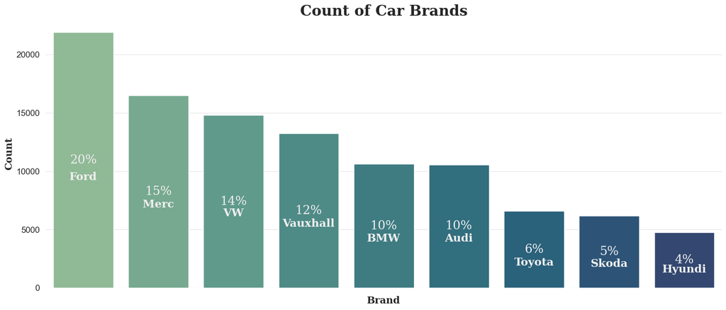

```python
fig, ax = plt.subplots(figsize=(20, 8))
# Edit the frame
plt.box(False)

sns.countplot(df_eda, x='brand', ax=ax, palette='crest',order=df_eda['brand'].value_counts().index)

ax.set_title("Count of Car Brands", fontfamily='serif', fontweight='bold', fontsize=24)
ax.set_xlabel('Brand', fontfamily='serif', fontsize=16, fontweight='bold')
ax.set_ylabel('Count', fontfamily='serif', fontsize=16, fontweight='bold')
ax.set_xticklabels([])
ax.tick_params(labelsize=14)

# Get actual numbers to anotate the plot
ford = df_eda['brand'].value_counts()['ford']
merc = df_eda['brand'].value_counts()['merc']
vw = df_eda['brand'].value_counts()['vw']
vauxhall = df_eda['brand'].value_counts()['vauxhall']
bmw = df_eda['brand'].value_counts()['bmw']
audi = df_eda['brand'].value_counts()['audi']
toyota = df_eda['brand'].value_counts()['toyota']
skoda = df_eda['brand'].value_counts()['skoda']
hyundi = df_eda['brand'].value_counts()['hyundi']
total = df_eda['brand'].value_counts().sum()

# Annotations

# Ford
plt.annotate(f"{int((ford/total)*100)}%", xy=(0, ford//2), fontfamily='serif', fontsize=20,
va='center', ha='center', color='#eeeeee')
plt.annotate(f"Ford", xy=(0, ford//2-ford//15), fontfamily='serif', fontsize=18, fontweight='bold',
va='center', ha='center', color='#eeeeee')

# Merc
plt.annotate(f"{int((merc/total)*100)}%", xy=(1, merc//2), fontfamily='serif', fontsize=20,
va='center', ha='center', color='#eeeeee')
plt.annotate(f"Merc", xy=(1, merc//2-merc//15), fontfamily='serif', fontsize=18, fontweight='bold',
va='center', ha='center', color='#eeeeee')

# VW
plt.annotate(f"{int((vw/total)*100)}%", xy=(2, vw//2), fontfamily='serif', fontsize=20,
va='center', ha='center', color='#eeeeee')
plt.annotate(f"VW", xy=(2, vw//2-vw//15), fontfamily='serif', fontsize=18, fontweight='bold',
va='center', ha='center', color='#eeeeee')

# Vauxhall
plt.annotate(f"{int((vauxhall/total)*100)}%", xy=(3, vauxhall//2), fontfamily='serif', fontsize=20,
va='center', ha='center', color='#eeeeee')
plt.annotate(f"Vauxhall", xy=(3, vauxhall//2-vauxhall//12), fontfamily='serif', fontsize=18, fontweight='bold',
va='center', ha='center', color='#eeeeee')

# BMW
plt.annotate(f"{int((bmw/total)*100)}%", xy=(4, bmw//2), fontfamily='serif', fontsize=20,
va='center', ha='center', color='#eeeeee')
plt.annotate(f"BMW", xy=(4, bmw//2-bmw//10), fontfamily='serif', fontsize=18, fontweight='bold',
va='center', ha='center', color='#eeeeee')

# Audi
plt.annotate(f"{int((audi/total)*100)}%", xy=(5, audi//2), fontfamily='serif', fontsize=20,
va='center', ha='center', color='#eeeeee')
plt.annotate(f"Audi", xy=(5, audi//2-audi//10), fontfamily='serif', fontsize=18, fontweight='bold',
va='center', ha='center', color='#eeeeee')

# Toyota
plt.annotate(f"{int((toyota/total)*100)}%", xy=(6, toyota//2), fontfamily='serif', fontsize=20,
va='center', ha='center', color='#eeeeee')
plt.annotate(f"Toyota", xy=(6, toyota//2-toyota//6), fontfamily='serif', fontsize=18, fontweight='bold',
va='center', ha='center', color='#eeeeee')

# Skoda
plt.annotate(f"{int((skoda/total)*100)}%", xy=(7, skoda//2), fontfamily='serif', fontsize=20,
va='center', ha='center', color='#eeeeee')
plt.annotate(f"Skoda", xy=(7, skoda//2-skoda//6), fontfamily='serif', fontsize=18, fontweight='bold',
va='center', ha='center', color='#eeeeee')

# Hyundi
plt.annotate(f"{int((hyundi/total)*100)}%", xy=(8, hyundi//2), fontfamily='serif', fontsize=20,
va='center', ha='center', color='#eeeeee')
plt.annotate(f"Hyundi", xy=(8, hyundi//2-hyundi//6), fontfamily='serif', fontsize=18, fontweight='bold',
va='center', ha='center', color='#eeeeee')

plt.show()
```

**Observations**:

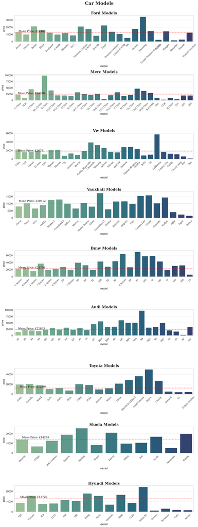

```python
# Get all the models for each brand
fig, ax = plt.subplots(9, 1, figsize=(15, 40))

car_brands = list(df_eda['brand'].value_counts().index)

fig.suptitle("Car Models", fontfamily='serif', fontweight='bold', fontsize=24)

for brand in car_brands:
    models = list(df_eda[df_eda['brand'] == brand]['model'].unique())
    # Plot the mean price for each model
    sns.barplot(data=df_eda[df_eda['brand'] == brand], x='model', y='price', ax=ax[car_brands.index(brand)], palette='crest', order=models, errorbar=None)
    ax[car_brands.index(brand)].set_title(f"{brand.capitalize()} Models", fontfamily='serif', fontweight='bold', fontsize=20)
    # Rotate the xticks
    ax[car_brands.index(brand)].set_xticklabels(labels=models, rotation=45, fontfamily='serif', fontsize=12)
    # Plot a horizontal line at the mean price
    ax[car_brands.index(brand)].axhline(df_eda[df_eda['brand'] == brand]['price'].mean(), linestyle='--', color='red', alpha=0.7)
    # Annotate the mean price
    ax[car_brands.index(brand)].annotate(f"Mean Price: £{int(df_eda[df_eda['brand'] == brand]['price'].mean())}", xy=(0, df_eda[df_eda['brand'] == brand]['price'].mean()+1000), fontfamily='serif', fontsize=14, color='black')

plt.tight_layout(rect=[0, 0, 1, 0.98])
plt.show()
```

**Observations**:

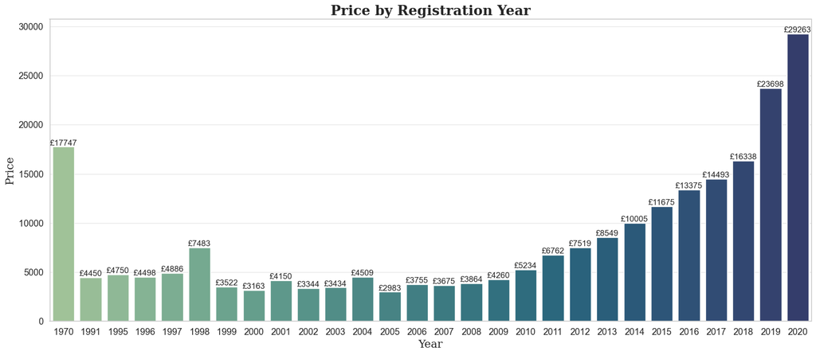

```python
fig, ax = plt.subplots(figsize=(20, 8))

sns.barplot(df_eda, x='year', y='price', ax=ax, errorbar=None, palette='crest')

ax.set_title("Price by Registration Year", fontfamily='serif', fontweight='bold', fontsize=20)
ax.set_xlabel('Year', fontfamily='serif', fontsize=16)
ax.set_ylabel('Price', fontfamily='serif', fontsize=16)
ax.bar_label(ax.containers[0], fmt='£%.0f', fontsize=12)

plt.show()
```

**Observations**:

- Generally, it seems that as the car registration year goes by, the car becomes more expensive which makes sense as newly registered cars are more expensive
- However, it seems that some older cars like from the 1970 are a lot more expensive. This is likely because the cars are considered classic cars with a limited supply. This could mean that the cars have some historical significance or have high collectible value

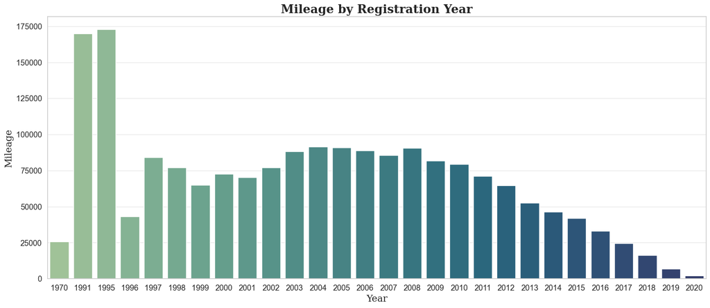

```python
fig, ax = plt.subplots(figsize=(20, 8))

sns.barplot(df_eda, x='year', y='mileage', ax=ax, errorbar=None, palette='crest')

ax.set_title("Mileage by Registration Year", fontfamily='serif', fontweight='bold', fontsize=20)
ax.set_xlabel('Year', fontfamily='serif', fontsize=16)
ax.set_ylabel('Mileage', fontfamily='serif', fontsize=16)

plt.show()
```

**Observations**:

- Generally, it seems that cars that have been registered for a longer time have a higher mileage
- The fact that cars from the 1970 have a very low mileage could likely be due to its limited useage or because it is stored controlled environments by classic car enthusiasts

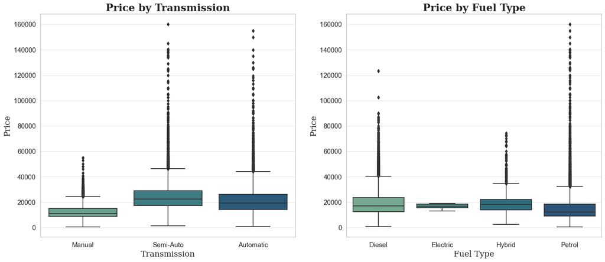

```python
fig, ax = plt.subplots(1, 2, figsize=(20, 8))

sns.boxplot(df_eda, x='transmission', y='price', ax=ax[0], palette='crest')

ax[0].set_title("Price by Transmission", fontfamily='serif', fontweight='bold', fontsize=20)
ax[0].set_xlabel('Transmission', fontfamily='serif', fontsize=16)
ax[0].set_ylabel('Price', fontfamily='serif', fontsize=16)

sns.boxplot(df_eda, x='fuelType', y='price', ax=ax[1], palette='crest')

ax[1].set_title("Price by Fuel Type", fontfamily='serif', fontweight='bold', fontsize=20)
ax[1].set_xlabel('Fuel Type', fontfamily='serif', fontsize=16)
ax[1].set_ylabel('Price', fontfamily='serif', fontsize=16)

plt.show()
```

**Observations**:

- It seems that Semi-Auto and Automatic cars are more expensive than manual cars when examining price by transmission
- Both diesel and hybrid cars seems to be slightly more expensive than petrol cars on average
- However, petrol cars have a lot more outliers of more expensive cars
- It seems that the spread of price of electric cars are very small but this is likely because there is not a lot of data of electric cars

#### **Pearon's r Correlation**

To check the correlation between the different numerical features, we will use Pearson's r correlation. The Pearson's r correlation is able to measure linear correlation between two variables.

**Formula**: $\begin{equation} \rho = \frac{COV(X,Y)}{\sigma_X\sigma_Y} \end{equation}$

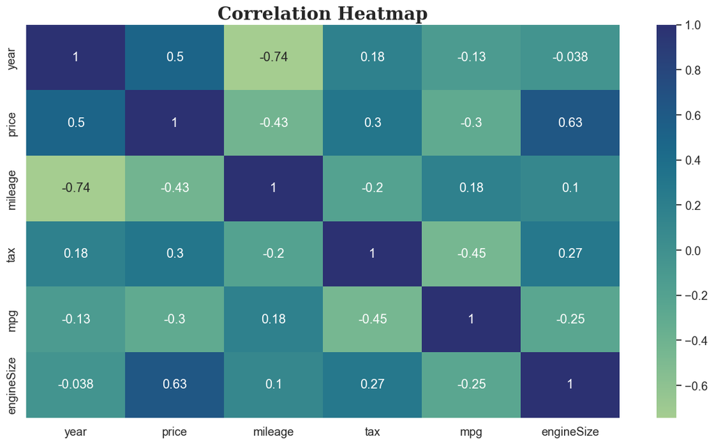

```python
plt.figure(figsize=(15,8))
sns.heatmap(df_eda.corr(), annot=True, cmap='crest')
plt.title("Correlation Heatmap", fontfamily='serif', fontweight='bold', fontsize=20)

plt.show()
```

**Observations**:

- From the correlation matrix, it seems that engineSize and year have a moderate linear relationship with price

## 2. Data Preparation

```python
X, y = df.drop('price', axis=1), df['price']
```

```python
# Split thge data into train and test sets
X_train, X_test, y_train, y_test = train_test_split(X, y, test_size=0.2, random_state=random_state)
```

```python
# Reset the index
X_train.reset_index(drop=True, inplace=True)
X_test.reset_index(drop=True, inplace=True)
y_train.reset_index(drop=True, inplace=True)
y_test.reset_index(drop=True, inplace=True)
```

```python
print("X_train shape: ", X_train.shape)
print("X_test shape: ", X_test.shape)
```

```
X_train shape:  (84173, 9)
X_test shape:  (21044, 9)
```

#### **Feature Engineering**

Feature Engineering is the process of creating new features from existing features in the dataset.

For this dataset, a possible feature can be *Mileage Per Year* which is defined as average yearly mileage of the car. This can then provide insights into the car's usage patterns

$$\begin{align} Mileage Per Year &= \frac{Mileage}{Age Of Car} \nonumber \\ &= \frac{Mileage}{2021 - Registration Year} \nonumber \end{align}$$

```python
X_featureEng, y_featureEng = X_train.copy(), y_train.copy()

# Create a new column called age
X_featureEng['mileagePerYear'] = X_featureEng['mileage']/(2021 - X_featureEng['year'])

print("NEW COLUMN: ")
display(X_featureEng[['mileagePerYear', 'mileage', 'year']].head())
```

```
NEW COLUMN:
```

|  | mileagePerYear | mileage | year |
| --- | --- | --- | --- |
| 0 | 396.500000 | 793 | 2019 |
| 1 | 7392.857143 | 51750 | 2014 |
| 2 | 2660.529412 | 45229 | 2004 |
| 3 | 2850.000000 | 5700 | 2019 |
| 4 | 7931.750000 | 31727 | 2017 |

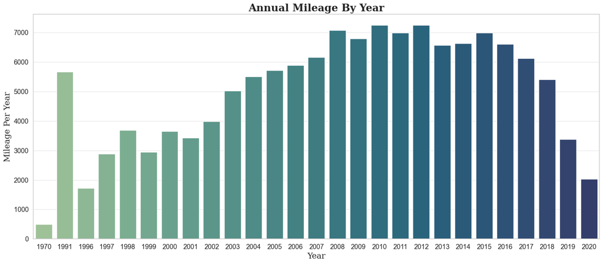

```python
# Check out the mileage per year
fig, ax = plt.subplots(figsize=(20, 8))

sns.barplot(x=X_featureEng['year'], y=X_featureEng['mileagePerYear'], ax=ax, errorbar=None, palette='crest')
ax.set_title("Annual Mileage By Year", fontfamily='serif', fontweight='bold', fontsize=20)
ax.set_xlabel('Year', fontfamily='serif', fontsize=16)
ax.set_ylabel('Mileage Per Year', fontfamily='serif', fontsize=16)

plt.show()
```

**Observations**:

- Generally, it seems that the annual mileage by year increases before it reaches around 2010 where it starts decreasing

#### **Categorical Encoding**

As our dataset contains categorical data and many machine learning models can only work with numerical values, it is necessary to transform the categorical values of relevant features into numerical ones. This process is known as encoding and there are several ways to encode our data:

1. One Hot Encoder
2. Label Encoder
3. Ordinal Encoder

We will be using One Hot Encoder for our categorical features that are nominal such as brand, model and fuelType while we will be using Ordinal Encoder for our categorical features that are Ordinal such as transmission

```python
X_enc, y_enc = X_train.copy(), y_train.copy()
warnings.filterwarnings('ignore')

# One hot encode the categorical columns
brand_categories = list(df.brand.unique())
model_categories = list(df.model.unique())
fuelType_categories = list(df.fuelType.unique())

brandOneHotEnc = OneHotEncoder(categories=[brand_categories], sparse=False, handle_unknown='ignore')
X_enc[brand_categories] = brandOneHotEnc.fit_transform(X_train[['brand']])
# Show brand categories and brand in the dataframe
print("ONE HOT ENCODED BRAND CATEGORIES: ")
display(X_enc[['brand'] + brand_categories].head())

modelOneHotEnc = OneHotEncoder(categories=[model_categories], sparse=False, handle_unknown='ignore')
X_enc[model_categories] = modelOneHotEnc.fit_transform(X_train[['model']])
# Show model categories and model in the dataframe
print("ONE HOT ENCODED MODEL CATEGORIES: ")
display(X_enc[['model'] + model_categories].head())

fuelTypeOneHotEnc = OneHotEncoder(categories=[fuelType_categories], sparse=False, handle_unknown='ignore')
X_enc[fuelType_categories] = fuelTypeOneHotEnc.fit_transform(X_train[['fuelType']])
# Show fuelType categories and fuelType in the dataframe
print("ONE HOT ENCODED FUEL TYPE CATEGORIES: ")
display(X_enc[['fuelType'] + fuelType_categories].head())

# Ordinal encode the transmission column
transmission_categories = ['Manual', 'Semi-Auto', 'Automatic']
transmissionOrdEnc = OrdinalEncoder(categories=[transmission_categories], handle_unknown='use_encoded_value', unknown_value=-1)
X_enc['transmission_enc'] = transmissionOrdEnc.fit_transform(X_train[['transmission']])
# Show transmission categories and transmission in the dataframe
print("ORDINAL ENCODED TRANSMISSION CATEGORIES: ")
display(X_enc[['transmission', 'transmission_enc']].head())
```

```
ONE HOT ENCODED BRAND CATEGORIES:
```

|  | brand | audi | bmw | merc | ford | hyundi | skoda | toyota | vauxhall | vw |
| --- | --- | --- | --- | --- | --- | --- | --- | --- | --- | --- |
| 0 | vw | 0.0 | 0.0 | 0.0 | 0.0 | 0.0 | 0.0 | 0.0 | 0.0 | 1.0 |
| 1 | toyota | 0.0 | 0.0 | 0.0 | 0.0 | 0.0 | 0.0 | 1.0 | 0.0 | 0.0 |
| 2 | toyota | 0.0 | 0.0 | 0.0 | 0.0 | 0.0 | 0.0 | 1.0 | 0.0 | 0.0 |
| 3 | audi | 1.0 | 0.0 | 0.0 | 0.0 | 0.0 | 0.0 | 0.0 | 0.0 | 0.0 |
| 4 | ford | 0.0 | 0.0 | 0.0 | 1.0 | 0.0 | 0.0 | 0.0 | 0.0 | 0.0 |

```
ONE HOT ENCODED MODEL CATEGORIES:
```

|  | model | A1 | A6 | A4 | A3 | Q3 | Q5 | A5 | S4 | Q2 | ... | Tiguan Allspace | Shuttle | Jetta | CC | California | Caddy Life | Caddy | Caddy Maxi | Eos | Fox |
| --- | --- | --- | --- | --- | --- | --- | --- | --- | --- | --- | --- | --- | --- | --- | --- | --- | --- | --- | --- | --- | --- |
| 0 | T-Cross | 0.0 | 0.0 | 0.0 | 0.0 | 0.0 | 0.0 | 0.0 | 0.0 | 0.0 | ... | 0.0 | 0.0 | 0.0 | 0.0 | 0.0 | 0.0 | 0.0 | 0.0 | 0.0 | 0.0 |
| 1 | Auris | 0.0 | 0.0 | 0.0 | 0.0 | 0.0 | 0.0 | 0.0 | 0.0 | 0.0 | ... | 0.0 | 0.0 | 0.0 | 0.0 | 0.0 | 0.0 | 0.0 | 0.0 | 0.0 | 0.0 |
| 2 | RAV4 | 0.0 | 0.0 | 0.0 | 0.0 | 0.0 | 0.0 | 0.0 | 0.0 | 0.0 | ... | 0.0 | 0.0 | 0.0 | 0.0 | 0.0 | 0.0 | 0.0 | 0.0 | 0.0 | 0.0 |
| 3 | A3 | 0.0 | 0.0 | 0.0 | 1.0 | 0.0 | 0.0 | 0.0 | 0.0 | 0.0 | ... | 0.0 | 0.0 | 0.0 | 0.0 | 0.0 | 0.0 | 0.0 | 0.0 | 0.0 | 0.0 |
| 4 | Focus | 0.0 | 0.0 | 0.0 | 0.0 | 0.0 | 0.0 | 0.0 | 0.0 | 0.0 | ... | 0.0 | 0.0 | 0.0 | 0.0 | 0.0 | 0.0 | 0.0 | 0.0 | 0.0 | 0.0 |

5 rows × 196 columns

```
ONE HOT ENCODED FUEL TYPE CATEGORIES:
```

|  | fuelType | Petrol | Diesel | Hybrid | Electric |
| --- | --- | --- | --- | --- | --- |
| 0 | Diesel | 0.0 | 1.0 | 0.0 | 0.0 |
| 1 | Hybrid | 0.0 | 0.0 | 1.0 | 0.0 |
| 2 | Petrol | 1.0 | 0.0 | 0.0 | 0.0 |
| 3 | Petrol | 1.0 | 0.0 | 0.0 | 0.0 |
| 4 | Diesel | 0.0 | 1.0 | 0.0 | 0.0 |

```
ORDINAL ENCODED TRANSMISSION CATEGORIES:
```

|  | transmission | transmission_enc |
| --- | --- | --- |
| 0 | Manual | 0.0 |
| 1 | Automatic | 2.0 |
| 2 | Automatic | 2.0 |
| 3 | Semi-Auto | 1.0 |
| 4 | Manual | 0.0 |

#### **Feature Scaling**

Feature Scaling is the process of scaling numerical features within the dataset to a similar scale.

Certain Machine Learning Algorithms such as `Gradient Descent Based Algorithms` (e.g. Linear Regression, Ridge Regression, Perceptron) and `Distance Based Algorithms` (e.g. KNNRegressor and SVR) are more sensitive to feature scaling and requires the data to be scaled.

On the other hand, `Tree Based Algorithms` (e.g. RandomForest, GradientBoosting) are more insensitive to the scale of the features since trees only split a node based on a single feature. This means that other features do not influence this split which explains why different features can be of different scales

There are two popular ways to perform Feature Scaling:

1. Normaliation
2. Standardization

Normalization

Normalization also known as Min-Max scaling, is a scaling technique in which values are shifted and rescaled so that they end up ranging between 0 and 1.

In SKLearn, Normalization can be implemented using `MinMaxScaler`

**Formula**:

$$\begin{equation} X' = \frac{X - X_{min}}{X_{max} - X_{min}} \nonumber \end{equation}$$

Standardization

Standardization is another scaling method where values are centered around the mean with a unit standard deviation. This means that the mean of the feautre becomes zero and the distribution of the scaled feature has a unit standard deviation (or a standard deviation of 1).

In SKlearn, Standardization can be implemented using `StandardScaler`

**Formula**:

$$\begin{equation} X' = \frac{X - \mu}{\sigma} \nonumber \end{equation}$$

Standardization vs Normalization

| Standardization | Normalization |
| --- | --- |
| Less Sensitive to outliers | Sensitive to outliers |
| Centers data around the mean and scales to a standard deviation of 1 | Rescales values to a range between 0 and 1 |
| Preserves the relationship between data points | May not preserve the relationship between the data points |
| Changes the shape of the original distribution | Retains the shape of the original distribution |

```python
X_enc_scaled, y_enc_scaled = X_enc.copy(), y_enc.copy()

# Scale the numeric columns
scaler = StandardScaler()

numeric_cols = ['year', 'mileage', 'tax', 'mpg', 'engineSize']

# Fit the scaler to the training data and transform
X_enc_scaled[numeric_cols] = scaler.fit_transform(X_enc[numeric_cols])
print("SCALED NUMERIC COLUMNS: ")
display(X_enc_scaled[numeric_cols].head())
```

```
SCALED NUMERIC COLUMNS:
```

|  | year | mileage | tax | mpg | engineSize |
| --- | --- | --- | --- | --- | --- |
| 0 | 0.908006 | -1.062414 | 0.373031 | -0.139874 | -0.124162 |
| 1 | -1.431480 | 1.337373 | -1.990732 | 1.007305 | 0.235235 |
| 2 | -6.110454 | 1.030271 | 3.388868 | -1.658394 | 0.594632 |
| 3 | 0.908006 | -0.831322 | 0.454541 | -0.875925 | -0.303860 |
| 4 | -0.027788 | 0.394403 | -1.990732 | 1.252655 | -0.303860 |

## 3. Model Selection

In order to select a model for hyperparameter tuning, we will run the preprocessed data through some models and deem the best model based on the evaluation metrics to be chosen later

#### **Pipeline**

First, we will use a pipeline to preprocess the data (the same way as done in part 2) since a pipeline can help:

1. Improve ML Workflow
2. Prevent Data Leakage from the Train subset into the Test subset

```python
# Redefine X_train and y_train to include feature engineering
X_train, y_train = X_featureEng, y_featureEng
```

```python
ordinal_features = ['transmission']
nominal_features = ['brand', 'model', 'fuelType']
numeric_features = ['year', 'mileage', 'tax', 'mpg', 'engineSize']

brand_categories = df.brand.unique()
model_categories = df.model.unique()
fuelType_categories = df.fuelType.unique()

# Transformer for numeric features
numericTransformer = ColumnTransformer(
    [
        ('scaler', StandardScaler(), numeric_features)
    ],
    remainder='passthrough'
)

# Transformer for categorical features
categoricalTransformer = ColumnTransformer(
    [
        ('ordinal', OrdinalEncoder(categories=[['Manual', 'Semi-Auto', 'Automatic']]), ordinal_features),
        ('brandOneHot', OneHotEncoder(categories=[brand_categories], sparse=False), ['brand']),
        ('modelOneHot', OneHotEncoder(categories=[model_categories], sparse=False), ['model']),
        ('fuelTypeOneHot', OneHotEncoder(categories=[fuelType_categories], sparse=False), ['fuelType'])
    ],
    remainder='passthrough'
)

preprocessor = ColumnTransformer(
    [
        ('numeric', numericTransformer, numeric_features),
        ('categorical', categoricalTransformer, nominal_features + ordinal_features)
    ],
    remainder='passthrough'
)

steps = [
    ('preprocessor', preprocessor),
    ('model')
]

model_step = len(steps) - 1
```

#### **Evaluation Metrics**

Mean Squared Error

Mean Squared Error is the sum of error at each point (error is the square of actual - predicted at a point) divided by the total number of points

**Formula**: $$ \begin{equation} MSE = \frac{\sum_{i=1}^{n} (y_i - \hat{y}_i)^2}{n} \nonumber \end{equation}$$

Root Mean Squared Error

Root Mean Squared Error the square root of the Mean Squared Error.

**Formula**: $$ \begin{equation} RMSE = \sqrt{\frac{\sum_{i=1}^{n} (y_i - \hat{y}_i)^2}{n}} \nonumber \end{equation}$$

R2

R2, also known as the coefficient of determinant, measures the proportion of variance in the dependent variable that can be explained by the independent variables in a regression model

**Formula**:

$$ \begin{equation} R^2 = 1 - \frac{\sum_{i=1}^{n} (y_i - \hat{y}_i)^2}{\sum_{i=1}^{n} (y_i - \bar{y})^2} \nonumber \end{equation}$$

```python
# Use scorers from sklearn.metrics for evaluation in cross validation
evaluation_metrics = {
    'RMSE': make_scorer(mean_squared_error, squared=False),
    'r2': 'r2'
}
```

```python
def plot_learning_curve(
    model,
    X,
    y,
    scoring,
    cv=KFold(shuffle=True, random_state=random_state),
    train_sizes=np.linspace(0.1, 1.0, 10),
    ax=None,
):
    try:
        model_name = type(model[-1].regressor).__name__
    except:
        try:
            model_name = type(model[-1]).__name__
        except:
            model_name = type(model).__name__

    if ax is None:
        fig, ax = plt.subplots(figsize=(10, 8))
    train_sizes, train_scores, test_scores, fit_times, _ = learning_curve(
        model,
        X,
        y,
        cv=cv,
        n_jobs=-1,
        train_sizes=train_sizes,
        return_times=True,
        scoring=scoring,
    )
    train_scores_mean = np.mean(train_scores, axis=1)
    test_scores_mean = np.mean(test_scores, axis=1)

    ax.plot(train_sizes, train_scores_mean, "o-", color="r", label="Training score")
    ax.plot(
        train_sizes, test_scores_mean, "o-", color="g", label="Cross-validation score"
    )
    ax.legend(loc="best")
    ax.set(
        ylim=(
            min(np.min(train_scores), np.min(test_scores)) - 0.1,
            1.0,
        )
    )
    ax.set_title(f"Learning Curve of {model_name}")
    ax.set_ylabel(f"{scoring}")
    ax.set_xlabel("Train Sizes")
    return ax
```

```python
# Instantiate the models
models = [
    ('Decision Tree Regressor', DecisionTreeRegressor(random_state=random_state)),
    ('Random Forest Regressor', RandomForestRegressor(random_state=random_state)),
    ('Gradient Boosting Regressor', GradientBoostingRegressor(random_state=random_state)),
    ('Ridge', Ridge(random_state=random_state)),
    ('Lasso', Lasso(random_state=random_state)),
    ('ElasticNet', ElasticNet(random_state=random_state)),
]
```

##### Models Explained

1. `Linear Regression`

Linear Regression is one of the most simple models for regression problems. It fits a linear function

$\begin{equation} f(x) = mx + c \nonumber \end{equation}$

to try and predict the value of a variable based on previous values

2. `Decision Tree`

A decision tree is the simplest of all tree-based model. The base of the tree is the root node and from the root node flows a series of decision nodes. Each decision node can then be split into further sub-nodes. Nodes that no longer split are called leaf or terminal nodes. The main contributor affecting the decision tree's accuracy is how each decision node is split

3. `Random Forest`

In Random Forest, bagging is used to generate multiple training sets with replacement (i.e. the initial dataset is divided into multiple datasets using randomized sampling). Then a single decision tree is built on each sample before the resultant prediction is combined using either voting or averaging in parallel

4. `Gradient Boosting`

Gradient Boosting is similar to Random Forest in that it is also made up of an ensemble of Decision Trees. However, instead of using a single tree to build on each sample, each new tree is built to improve on the deficiencies of the previous tree (also known as boosting). This is done by minimising the loss function as the algorithm builds each tree

5. `Ridge`

Ridge Regression performs L2 regularization for a linear regression model to prevent it from overfitting.

$$ \begin{align} Ridge(w,b) &= error function + L2 regularization term \nonumber \\ &= \frac{1}{n}\sum_{i=1}^{n} (y_i - \hat{y}_i)^2 + \lambda \sum_{j=1}^{p} w_{j}^{2} \nonumber \end{align}$$

In Ridge Regression, the coefficient can be reduced but it will never reach 0 (none of the features will be removed)

6. `Lasso`

Lasso Regression performs L1 regularization for a linear regression model to prevent it from overfitting.

$$ \begin{align} Lasso(w,b) &= error function + L1 regularization term \nonumber \\ &= \frac{1}{n}\sum_{i=1}^{n} (y_i - \hat{y}_i)^2 + \lambda \sum_{j=1}^{p} |w_{j}| \nonumber \end{align}$$

In Lasso Regression, it is possible for the coefficient of a feature to be reduced to 0 (the feature is removed)

7. `ElasticNet`

Elastic Net combines L1 and L2 as a regularizer. l1_ratio is used as the mixing parameter

$\begin{equation} regularization term = \lambda \sum_{j=1}^{p} (l1_{ratio} \cdot |w_{j}| + (1-l1_{ratio}) \cdot w_{j}^{2}) \nonumber \end{equation}$

|  | fit_time | score_time | test_RMSE | test_r2 |
| --- | --- | --- | --- | --- |
| Random Forest Regressor | 142.59574 | 0.81743 | 2072.87772 | 0.95500 |
| Decision Tree Regressor | 3.31577 | 0.10936 | 2560.14155 | 0.93134 |
| Gradient Boosting Regressor | 115.10424 | 0.14034 | 3118.21091 | 0.89856 |
| Ridge | 0.70207 | 0.10303 | 3658.88309 | 0.86033 |
| Lasso | 24.24087 | 0.06560 | 3684.97777 | 0.85833 |
| ElasticNet | 1.32064 | 0.09600 | 5454.13036 | 0.68977 |

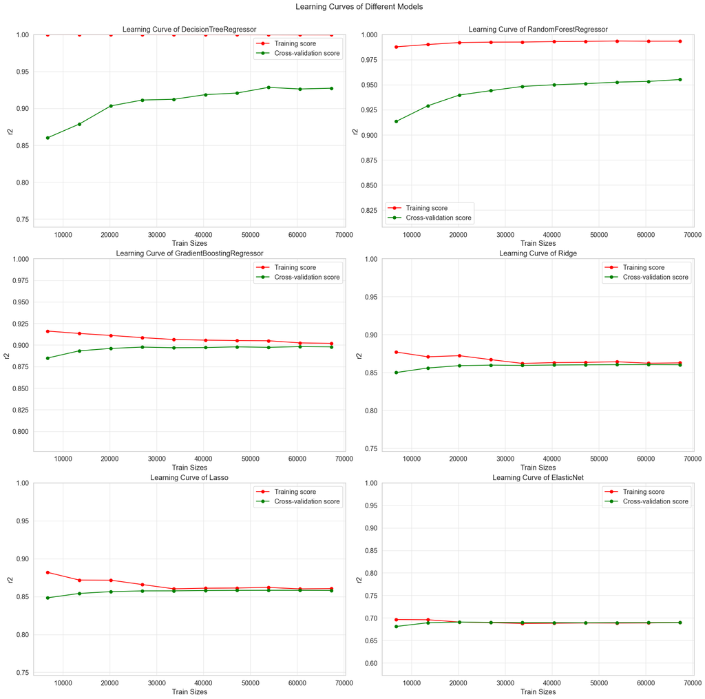

```python
# 26m
Final_Score = pd.DataFrame()

fig,ax = plt.subplots(3, 2, figsize=(20, 20))
fig.set_facecolor('white')
# Set title
fig.suptitle("Learning Curves of Different Models", fontsize=16)

# Set padding between each subplot
fig.tight_layout(pad=2.5)

for name, model in models:
    steps[model_step] = ('model', model)
    pipe = Pipeline(steps=steps)
    # Plot learning curve
    plot_learning_curve(
            pipe,
            X_train,
            y_train,
            scoring='r2',
            ax=ax[models.index((name, model))//2, models.index((name, model))%2]
        )
    # Cross validate
    scores = pd.DataFrame(cross_validate(pipe, X_train, y_train, scoring=evaluation_metrics, cv=5, return_train_score=False, n_jobs=-1)).mean(axis=0)
    Final_Score[name] = scores

with pd.option_context('display.float_format', '{:.5f}'.format):
    display(Final_Score.sort_values(
        by=[
            'test_r2',
            'test_RMSE'
        ],
        ascending=False,
        axis=1
    ).T)
```

**Observations**:

- From the scores, it seems that both Ridge and Lasso are not doing that bad themselves.
- Generally, the tree based models have a better performance compared to the gradient descent based models with an r2 of about 0.9 and a RMSE of around 2k-3k

We will be selecting three models for hyperparameter tuning. They are:

- Decision Tree
- Random Forest
- Gradient Boosting

**Initializing Decision Tree**

```python
# Decision Tree (12s)
steps[model_step] = ('model', DecisionTreeRegressor(random_state=random_state))

tree = Pipeline(steps=steps)
tree.fit(X_train, y_train)
scores = pd.DataFrame(cross_validate(
    tree,
    X_train,
    y_train,
    cv=10,
    scoring=evaluation_metrics,
    n_jobs=-1,
    return_train_score=True,
))
scores.loc['mean'] = scores.mean(axis=0)
# displaying scores
display(scores)
```

|  | fit_time | score_time | test_RMSE | train_RMSE | test_r2 | train_r2 |
| --- | --- | --- | --- | --- | --- | --- |
| 0 | 5.610270 | 0.108416 | 2460.900018 | 208.986184 | 0.932343 | 0.999548 |
| 1 | 5.638276 | 0.106411 | 2292.467926 | 208.500100 | 0.946810 | 0.999545 |
| 2 | 5.383459 | 0.066213 | 2735.026221 | 203.416402 | 0.924993 | 0.999567 |
| 3 | 5.606270 | 0.113416 | 2474.443220 | 206.349370 | 0.935884 | 0.999556 |
| 4 | 5.542670 | 0.080608 | 2844.126027 | 203.010318 | 0.917731 | 0.999569 |
| 5 | 5.619273 | 0.109416 | 2320.116621 | 213.365349 | 0.941297 | 0.999528 |
| 6 | 5.462655 | 0.080168 | 2456.386628 | 213.982262 | 0.936706 | 0.999523 |
| 7 | 5.551946 | 0.109185 | 2401.940706 | 201.284348 | 0.941830 | 0.999576 |
| 8 | 5.621119 | 0.083416 | 2977.439850 | 204.615730 | 0.907472 | 0.999563 |
| 9 | 5.466522 | 0.083597 | 2720.569411 | 204.026031 | 0.922090 | 0.999566 |
| mean | 5.550246 | 0.094085 | 2568.341663 | 206.753609 | 0.930716 | 0.999554 |

**Initializing RandomForest**

```python
# Random Forest (5m 18s)
steps[model_step] = ('model', RandomForestRegressor(random_state=random_state))

rf = Pipeline(steps=steps)
rf.fit(X_train, y_train)
scores = pd.DataFrame(cross_validate(
    rf,
    X_train,
    y_train,
    cv=10,
    scoring=evaluation_metrics,
    n_jobs=-1,
    return_train_score=True,
))
scores.loc['mean'] = scores.mean(axis=0)
# displaying scores
display(scores)
```

|  | fit_time | score_time | test_RMSE | train_RMSE | test_r2 | train_r2 |
| --- | --- | --- | --- | --- | --- | --- |
| 0 | 286.888639 | 1.213772 | 1914.729829 | 780.814753 | 0.959042 | 0.993689 |
| 1 | 291.187505 | 1.332394 | 1876.612547 | 787.045224 | 0.964357 | 0.993519 |
| 2 | 291.376507 | 1.278847 | 1925.835271 | 786.814424 | 0.962811 | 0.993515 |
| 3 | 287.747412 | 1.341721 | 2087.181431 | 777.739751 | 0.954383 | 0.993695 |
| 4 | 291.290505 | 1.295846 | 2311.148923 | 780.556501 | 0.945675 | 0.993629 |
| 5 | 290.301274 | 1.211236 | 1870.491318 | 797.212187 | 0.961845 | 0.993404 |
| 6 | 293.682703 | 2.332868 | 1969.263383 | 781.969290 | 0.959320 | 0.993628 |
| 7 | 291.960749 | 1.532852 | 1927.304369 | 788.233796 | 0.962548 | 0.993496 |
| 8 | 294.281622 | 1.572265 | 2375.095795 | 765.610822 | 0.941123 | 0.993888 |
| 9 | 287.811317 | 1.234723 | 2101.019961 | 784.846313 | 0.953534 | 0.993583 |
| mean | 290.652823 | 1.434652 | 2035.868283 | 783.084306 | 0.956464 | 0.993605 |

**Initializing Gradient Boosting**

```python
# Gradient Boosting (5m 16s)
steps[model_step] = ('model', GradientBoostingRegressor(random_state=random_state))

gb = Pipeline(steps=steps)
gb.fit(X_train, y_train)
scores = pd.DataFrame(cross_validate(
    gb,
    X_train,
    y_train,
    cv=10,
    scoring=evaluation_metrics,
    n_jobs=-1,
    return_train_score=True,
))
scores.loc['mean'] = scores.mean(axis=0)
# displaying scores
display(scores)
```

|  | fit_time | score_time | test_RMSE | train_RMSE | test_r2 | train_r2 |
| --- | --- | --- | --- | --- | --- | --- |
| 0 | 304.784509 | 0.146005 | 2967.821450 | 3080.846431 | 0.901599 | 0.901745 |
| 1 | 304.311669 | 0.118005 | 3037.883671 | 3086.235063 | 0.906596 | 0.900338 |
| 2 | 306.053048 | 0.164526 | 3137.026854 | 3088.068667 | 0.901323 | 0.900112 |
| 3 | 305.601609 | 0.124998 | 3188.378642 | 3061.527108 | 0.893549 | 0.902302 |
| 4 | 305.699608 | 0.148293 | 3309.150698 | 3045.016750 | 0.888629 | 0.903036 |
| 5 | 302.914540 | 0.144019 | 2982.743784 | 3079.139954 | 0.902977 | 0.901607 |
| 6 | 304.841095 | 0.144998 | 3055.043461 | 3070.800393 | 0.902095 | 0.901729 |
| 7 | 305.381887 | 0.150006 | 3161.286269 | 3059.567672 | 0.899236 | 0.902009 |
| 8 | 304.902106 | 0.112987 | 3341.347059 | 3038.260844 | 0.883472 | 0.903747 |
| 9 | 305.799498 | 0.156120 | 3079.424277 | 3097.101751 | 0.900181 | 0.900073 |
| mean | 305.028957 | 0.140996 | 3126.010616 | 3070.656463 | 0.897966 | 0.901670 |

**Compare model with dummy baseline**

```python
# Dummy Classifier
dummy_reg = Pipeline(steps=steps)

steps[model_step] = ("model", DummyRegressor(strategy="median"))

dummy_reg = Pipeline(steps=steps)
dummy_reg.fit(X_train, y_train)
scores = pd.DataFrame(cross_validate(
    dummy_reg,
    X_train,
    y_train,
    cv=10,
    scoring=evaluation_metrics,
    n_jobs=-1,
    return_train_score=True,
))
scores.loc['mean'] = scores.mean(axis=0)
# displaying scores
display(scores)
```

|  | fit_time | score_time | test_RMSE | train_RMSE | test_r2 | train_r2 |
| --- | --- | --- | --- | --- | --- | --- |
| 0 | 0.745887 | 0.184223 | 9718.526852 | 10110.489172 | -0.055176 | -0.058180 |
| 1 | 0.673589 | 0.180303 | 10219.188209 | 10055.484716 | -0.056950 | -0.057985 |
| 2 | 0.770465 | 0.131414 | 10259.575824 | 10050.913673 | -0.055455 | -0.058159 |
| 3 | 0.830768 | 0.108623 | 10039.416089 | 10075.587317 | -0.055421 | -0.058154 |
| 4 | 0.889456 | 0.079036 | 10184.250176 | 10052.951424 | -0.054868 | -0.056861 |
| 5 | 0.907469 | 0.157568 | 9841.746678 | 10097.232185 | -0.056300 | -0.058054 |
| 6 | 0.900197 | 0.136369 | 10046.577891 | 10074.794136 | -0.058781 | -0.057779 |
| 7 | 0.808506 | 0.096954 | 10251.208480 | 10051.864992 | -0.059562 | -0.057691 |
| 8 | 0.787919 | 0.129037 | 10072.348081 | 10071.934846 | -0.058884 | -0.057767 |
| 9 | 0.876828 | 0.098918 | 10067.166049 | 10072.510464 | -0.066814 | -0.056932 |
| mean | 0.819108 | 0.130245 | 10070.000433 | 10071.376292 | -0.057821 | -0.057756 |

We will be comparing our three models with a dummy baseline model. The comparison will be done through:

- Residual Plot
- Prediction Error Plot
- Learning Curve

**Residual Plot**

```python
def plot_residuals(model, X, y, ax=None):
    if ax is None:
        fig, ax = plt.subplots(figsize=(10, 8))

    try:
        model_name = type(model[-1].regressor).__name__
    except:
        try:
            model_name = type(model[-1]).__name__
        except:
            model_name = type(model).__name__

    y_pred = model.predict(X)
    residuals = y - y_pred

    ax.scatter(range(len(residuals)), residuals, alpha=0.5)

    ax.set_xlabel("Predicted Values", fontfamily='serif', fontsize=14)
    ax.set_ylabel("Residuals", fontfamily='serif', fontsize=14)
    ax.set_title(f"Residual Plot of {model_name}", fontfamily='serif', fontsize=16)
    ax.axhline(0, color="red", linestyle='--')

    return ax
```

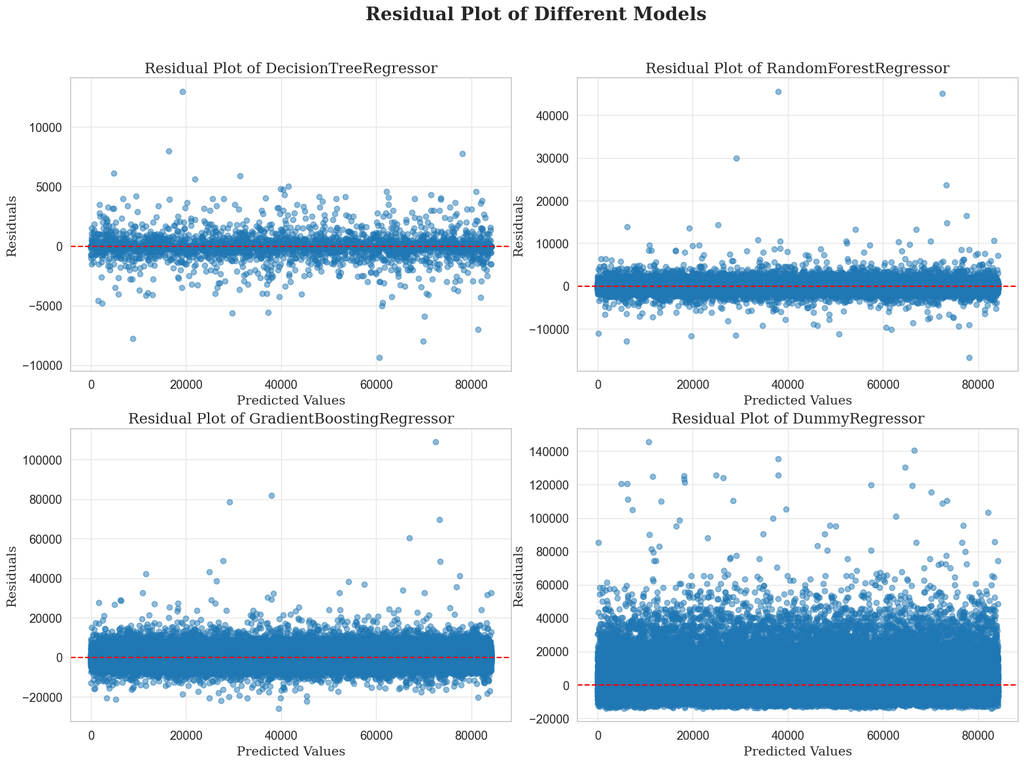

```python
# Plot residual plot
fig, ax = plt.subplots(2, 2, figsize=(16, 12))

fig.suptitle("Residual Plot of Different Models", fontsize=20, fontweight='bold', fontfamily='serif')

fig.tight_layout(pad=2.5)

# Ridge
plot_residuals(
    tree,
    X_train,
    y_train,
    ax=ax[0, 0],
)

# Ridge
plot_residuals(
    rf,
    X_train,
    y_train,
    ax=ax[0, 1],
)

# Gradient Boosting
plot_residuals(
    gb,
    X_train,
    y_train,
    ax=ax[1, 0],
)

# Dummy Classifier
plot_residuals(
    dummy_reg,
    X_train,
    y_train,
    ax=ax[1, 1],
)

plt.show()
```

**Observations**:

- From the residual plot, it seems that Decision Tree and Random Forest seem to be performing better than Gradient Boosting since most of the residuals are closer to the horizontal line at 0
- Furthermore, they also seem to have far fewer outliers with outliers of positive residuals reaching only around 10,000 for decision tree and 40,000 for Random Forest while for Gradient Boosting, there are positive residuals of up to 100,000
- Overall, it seems that the DummyRegressor is the worst performing with a lot of the residuals not lying near the red horizontal line at 0 and with extreme outliers at values of around 140,000

**Prediction Error Plot**

```python
def plot_prediction_error(model, X, y, ax=None):
    if ax is None:
        fig, ax = plt.subplots(figsize=(10, 8))
    try:
        model_name = type(model[-1].regressor).__name__
    except:
        try:
            model_name = type(model[-1]).__name__
        except:
            model_name = type(model).__name__

    y_pred = model.predict(X)

    ax.scatter(y, y_pred, c="red", marker='x')
    p1 = max(max(y_pred), max(y_test))
    p2 = min(min(y_pred), min(y_test))
    ax.plot([p1, p2], [p1, p2], "b--", label="Identity")
    a, b = np.polyfit(y, y_pred, 1)
    ax.plot(y, a * y + b, "g-", label="Best Fit")
    ax.legend()
    ax.set_xlabel("True Values")
    ax.set_ylabel("Predictions")
    ax.set_title(f"Prediction Error Plot using {model_name}")
    print(f"{model_name}'s R2: {r2_score(y,y_pred):.3f}")
    return ax
```

```
DecisionTreeRegressor's R2: 1.000
RandomForestRegressor's R2: 0.994
GradientBoostingRegressor's R2: 0.902
DummyRegressor's R2: -0.058
```

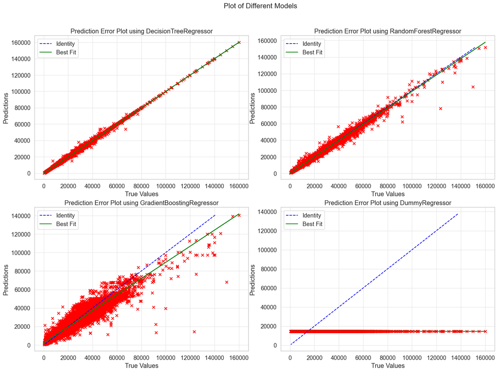

```python
# Plot prediction error plot
fig, ax = plt.subplots(2, 2, figsize=(16, 12))

fig.suptitle("Plot of Different Models", fontsize=16)

fig.tight_layout(pad=2.5)

# Ridge
plot_prediction_error(
    tree,
    X_train,
    y_train,
    ax=ax[0, 0],
)

# ElasticNet
plot_prediction_error(
    rf,
    X_train,
    y_train,
    ax=ax[0, 1],
)

# Gradient Boosting
plot_prediction_error(
    gb,
    X_train,
    y_train,
    ax=ax[1, 0],
)

# Dummy Classifier
plot_prediction_error(
    dummy_reg,
    X_train,
    y_train,
    ax=ax[1, 1],
)

plt.show()
```

A prediction error plot shows the actual targets from the dataset against the predicted values generated by the model. The 45 degree line ,also known as the identity line, is the line where the prediction exactly matches the model

**Observations**:

- We notice that DummyRegressor's best fit line is very far away from the identity line which suggests that the model completely does no folLow the trend of the prices
- Both Random Forest and the Decision Tree's best fit line is almost identicial to the identity line which suggests that they have a much better performance compared to Gradient Boosting where the best fit line is still at a slight angle away from the identity line

**Learning Curve**

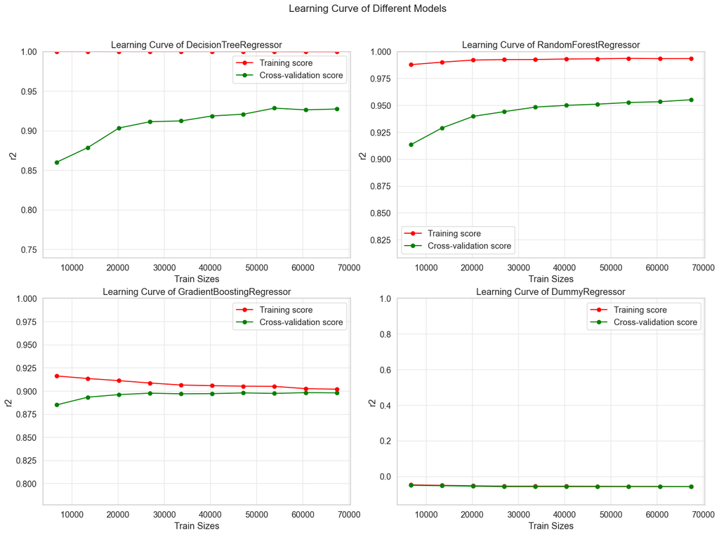

```python
# Plot learning curve
fig, ax = plt.subplots(2, 2, figsize=(16, 12))

fig.suptitle("Learning Curve of Different Models", fontsize=16)

fig.tight_layout(pad=2.5)

# Ridge
plot_learning_curve(
    tree,
    X_train,
    y_train,
    scoring='r2',
    ax=ax[0, 0],
)

# Ridge
plot_learning_curve(
    rf,
    X_train,
    y_train,
    scoring='r2',
    ax=ax[0, 1],
)

# Gradient Boosting
plot_learning_curve(
    gb,
    X_train,
    y_train,
    scoring='r2',
    ax=ax[1, 0],
)

# Dummy Classifier
plot_learning_curve(
    dummy_reg,
    X_train,
    y_train,
    scoring='r2',
    ax=ax[1, 1],
)

plt.show()
```

**Observations**:

- From the learning curve, it seems that DummyRegressor completely underfits with a negative r2 value
- All the other models seem to improve their Cross-Validation scores when there is a bigger train size
- The r2 scores of all three models are quite similar at around 0.9
- Decision Tree and Random Forest have a higher training score of close to 1.0 while Gradient Boosting has a slightly lower training score of around 0.9 which is closer to its cross-validation score

## 4. Model Improvement

In order to try and improve the performance of our models, we can try to tune the hyperparameters of the model

```python
print('Decision Tree Regressor: ')
print(list(DecisionTreeRegressor().get_params().keys()))
```

```
Decision Tree Regressor:
['ccp_alpha', 'criterion', 'max_depth', 'max_features', 'max_leaf_nodes', 'min_impurity_decrease', 'min_samples_leaf', 'min_samples_split', 'min_weight_fraction_leaf', 'random_state', 'splitter']
```

```python
print('Random Forest Regressor: ')
print(list(RandomForestRegressor().get_params().keys()))
```

```
Random Forest Regressor:
['bootstrap', 'ccp_alpha', 'criterion', 'max_depth', 'max_features', 'max_leaf_nodes', 'max_samples', 'min_impurity_decrease', 'min_samples_leaf', 'min_samples_split', 'min_weight_fraction_leaf', 'n_estimators', 'n_jobs', 'oob_score', 'random_state', 'verbose', 'warm_start']
```

```python
print('Gradient Boosting Regressor: ')
print(list(GradientBoostingRegressor().get_params().keys()))
```

```
Gradient Boosting Regressor:
['alpha', 'ccp_alpha', 'criterion', 'init', 'learning_rate', 'loss', 'max_depth', 'max_features', 'max_leaf_nodes', 'min_impurity_decrease', 'min_samples_leaf', 'min_samples_split', 'min_weight_fraction_leaf', 'n_estimators', 'n_iter_no_change', 'random_state', 'subsample', 'tol', 'validation_fracti…
```

**Hyperparameter Tuning and Evaluation**

We will be using GridSearchCV to run through the parameters and see which model's parameter will give the best r2

Hyperparameters to be tuned

- Decision Tree
  - max_leaf_nodes - maximum number of leaf nodes
- Random Forest
  - max_leaf_nodes - maximum number of leaf nodes
  - n_estimators - number of trees in the forest
- Gradient Boosting
  - max_leaf_nodes - maximum number of leaf nodes
  - n_estimators - number of trees in the forest

Hyperparameter tuning for decision tree

```python
params_grid = {
    "criterion": ["squared_error", "friedman_mse"],
    "max_leaf_nodes": [100, 200, 500, 1000, 2000],
}

# Grid Search CV
grid_search = GridSearchCV(
    DecisionTreeRegressor(random_state=random_state),
    params_grid,
    scoring='r2',
    n_jobs=-1,
    cv=5,
    verbose=1
)

steps[model_step] = ('tuning', grid_search)

tree_gridSearch = Pipeline(steps=steps)

# Fitting model
tree_gridSearch.fit(X_train, y_train)

print(tree_gridSearch.named_steps["tuning"].best_estimator_)
print(tree_gridSearch.named_steps["tuning"].best_params_)
print(tree_gridSearch.named_steps["tuning"].best_score_)
```

```
Fitting 5 folds for each of 10 candidates, totalling 50 fits
DecisionTreeRegressor(max_leaf_nodes=2000, random_state=42)
{'criterion': 'squared_error', 'max_leaf_nodes': 2000}
0.9375282517079875
```

```python
# 1 h 30 min
params_grid = {
    "max_leaf_nodes": [500, 1000, 2000],
    "n_estimators": [100, 500],
}

# Grid Search CV
grid_search = GridSearchCV(
    RandomForestRegressor(random_state=random_state),
    params_grid,
    scoring='r2',
    n_jobs=-1,
    cv=5,
    verbose=1
)

steps[model_step] = ('tuning', grid_search)

rf_gridSearch = Pipeline(steps=steps)

# Fitting model
rf_gridSearch.fit(X_train, y_train)

print(rf_gridSearch.named_steps["tuning"].best_estimator_)
print(rf_gridSearch.named_steps["tuning"].best_params_)
print(rf_gridSearch.named_steps["tuning"].best_score_)
```

```
Fitting 5 folds for each of 6 candidates, totalling 30 fits
RandomForestRegressor(max_leaf_nodes=2000, n_estimators=500, random_state=42)
{'max_leaf_nodes': 2000, 'n_estimators': 500}
0.9535932785805386
```

```python
# 3 h
params_grid = {
    "max_leaf_nodes": [500, 1000, 2000],
    "n_estimators": [100, 500],
}

# Grid Search CV
grid_search = GridSearchCV(
    GradientBoostingRegressor(random_state=random_state),
    params_grid,
    scoring='r2',
    n_jobs=-1,
    cv=5,
    verbose=1
)

steps[model_step] = ('tuning', grid_search)

gb_gridSearch = Pipeline(steps=steps)

# Fitting model
gb_gridSearch.fit(X_train, y_train)

print(gb_gridSearch.named_steps["tuning"].best_estimator_)
print(gb_gridSearch.named_steps["tuning"].best_params_)
print(gb_gridSearch.named_steps["tuning"].best_score_)
```

```
Fitting 5 folds for each of 6 candidates, totalling 30 fits
GradientBoostingRegressor(max_leaf_nodes=500, n_estimators=500, random_state=42)
{'max_leaf_nodes': 500, 'n_estimators': 500}
0.9380563072568447
```

**Model Evaluation**

We will now evaluate the model on an independent test set to see if the model can generalize well to unseen examples

```python
print(y_test.shape)
```

```
(21044,)
```

**Initiate model after hyperparameter tuning**

```python
# Add the new column to the test set'
X_test['mileagePerYear'] = X_test['mileage']/(2021 - X_test['year'])
```

```python
steps[model_step] = ("model", tree_gridSearch.named_steps["tuning"].best_estimator_)
tuned_tree = Pipeline(steps)
# Fit the model
tuned_tree.fit(X_train, y_train)
# Predict the values
tree_y_pred = tuned_tree.predict(X_test)
```

```python
steps[model_step] = ("model", rf_gridSearch.named_steps["tuning"].best_estimator_)
tuned_rf = Pipeline(steps)
# Fit the model
tuned_rf.fit(X_train, y_train)
# Predict the values
rf_y_pred = tuned_rf.predict(X_test)
```

```python
steps[model_step] = ("model", gb_gridSearch.named_steps["tuning"].best_estimator_)
tuned_gb = Pipeline(steps)
# Fit the model
tuned_gb.fit(X_train, y_train)
# Predict the values
gb_y_pred = tuned_gb.predict(X_test)
```

**Comparing the tuned models**

Now, the models will be compared using:

- Residual Plot
- Prediction Error Plot

**Residual Plot**

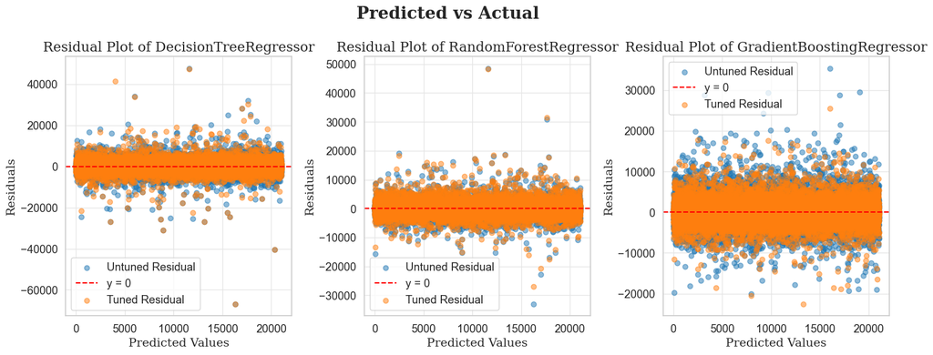

```python
fig, ax = plt.subplots(1, 3, figsize=(15, 6))

fig.suptitle("Predicted vs Actual", fontsize=20, fontweight='bold', fontfamily='serif')

# Untuned Tree
plot_residuals(
    tree,
    X_test,
    y_test,
    ax=ax[0],
)

# Tuned Tree
plot_residuals(
    tuned_tree,
    X_test,
    y_test,
    ax=ax[0],
)

# Set legend for the first plot
ax[0].legend(
    [
        "Untuned Residual",
        "y = 0",
        "Tuned Residual"
    ],
    loc="best",
)

# Untuned Random Forest
plot_residuals(
    rf,
    X_test,
    y_test,
    ax=ax[1],
)

# Tuned Random Forest
plot_residuals(
    tuned_rf,
    X_test,
    y_test,
    ax=ax[1],
)

# Set legend for the second plot
ax[1].legend(
    [
        "Untuned Residual",
        "y = 0",
        "Tuned Residual"
    ],
    loc="best",
)

# Untuned Gradient Boosting
plot_residuals(
    gb,
    X_test,
    y_test,
    ax=ax[2],
)

# Tuned Gradient Boosting
plot_residuals(
    tuned_gb,
    X_test,
    y_test,
    ax=ax[2],
)

# Set legend for the third plot
ax[2].legend(
    [
        "Untuned Residual",
        "y = 0",
        "Tuned Residual"
    ],
    loc="best",
)

plt.tight_layout()
plt.show()
```

**Prediction Error Plot**

```
UNTUNED MODELS:

DecisionTreeRegressor's R2: 0.939
RandomForestRegressor's R2: 0.965
GradientBoostingRegressor's R2: 0.907
TUNED MODELS:

DecisionTreeRegressor's R2: 0.947
RandomForestRegressor's R2: 0.963
GradientBoostingRegressor's R2: 0.946
```

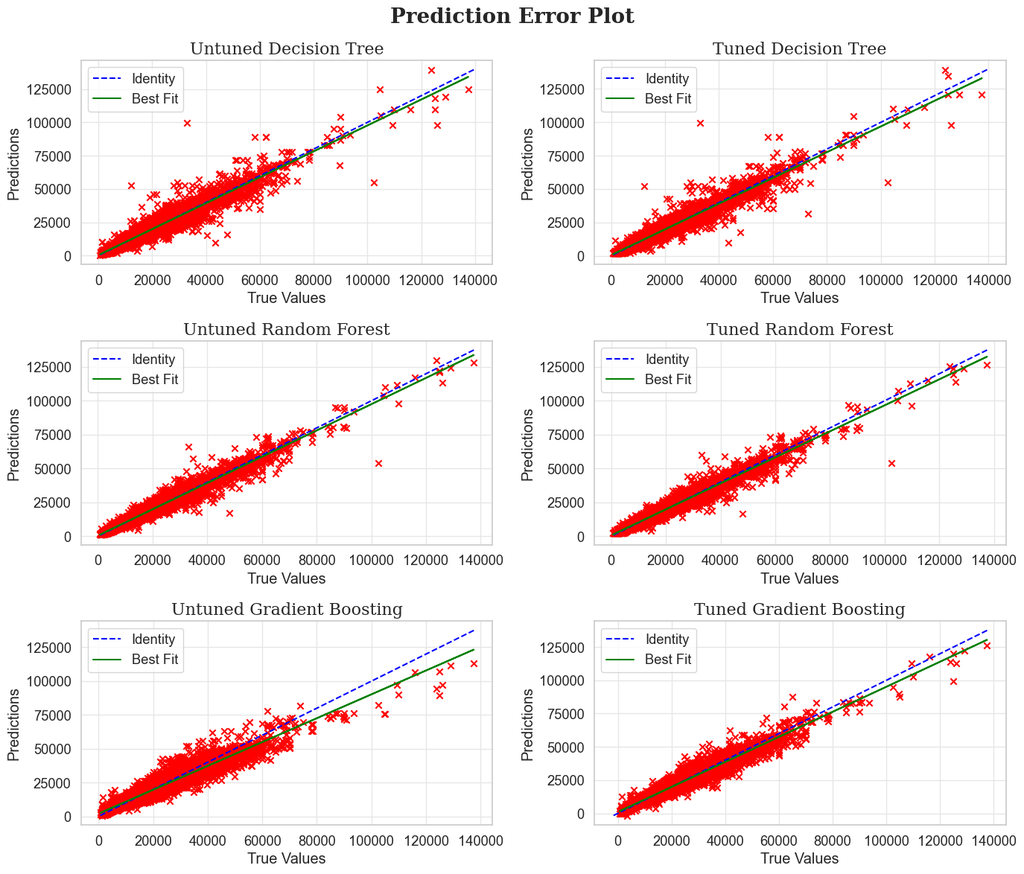

```python
fig, ax = plt.subplots(3, 2, figsize=(14, 12))

fig.suptitle("Prediction Error Plot", fontsize=20, fontweight='bold', fontfamily='serif')

print("UNTUNED MODELS:\n")

# Untuned Tree
plot_prediction_error(
    tree,
    X_test,
    y_test,
    ax=ax[0, 0],
)

# Untuned Random Forest
plot_prediction_error(
    rf,
    X_test,
    y_test,
    ax=ax[1, 0],
)

# Untuned Gradient Boosting
plot_prediction_error(
    gb,
    X_test,
    y_test,
    ax=ax[2, 0],
)

print("TUNED MODELS:\n")

# Tuned Tree
plot_prediction_error(
    tuned_tree,
    X_test,
    y_test,
    ax=ax[0, 1],
)

# Tuned Random Forest
plot_prediction_error(
    tuned_rf,
    X_test,
    y_test,
    ax=ax[1, 1],
)

# Tuned Gradient Boosting
plot_prediction_error(
    tuned_gb,
    X_test,
    y_test,
    ax=ax[2, 1],
)

# Overwrite title
ax[0, 0].set_title("Untuned Decision Tree", fontfamily='serif', fontsize=16)
ax[1, 0].set_title("Untuned Random Forest", fontfamily='serif', fontsize=16)
ax[2, 0].set_title("Untuned Gradient Boosting", fontfamily='serif', fontsize=16)

ax[0, 1].set_title("Tuned Decision Tree", fontfamily='serif', fontsize=16)
ax[1, 1].set_title("Tuned Random Forest", fontfamily='serif', fontsize=16)
ax[2, 1].set_title("Tuned Gradient Boosting", fontfamily='serif', fontsize=16)

plt.tight_layout()
plt.show()
```

**Observations**:

- Generally, for the decision tree and gradient boosting, they have a best fit line that got closer to the identity line after tuning
- For Random Forest, the difference in the change in best fit line does not seem to be as significant

**Observations**:

```python
pred_scores = pd.DataFrame(
    [
        [
            mean_squared_error(y_test, tree_y_pred, squared=False),
            mean_squared_error(y_test, rf_y_pred, squared=False),
            mean_squared_error(y_test, gb_y_pred, squared=False)
        ],
        [
            r2_score(y_test, tree_y_pred),
            r2_score(y_test, rf_y_pred),
            r2_score(y_test, gb_y_pred)
        ]
    ],
    index=['RMSE', 'R2'],
    columns=['Decision Tree', 'Random Forest', 'Gradient Boosting']
)

display(pred_scores)
```

|  | Decision Tree | Random Forest | Gradient Boosting |
| --- | --- | --- | --- |
| RMSE | 2276.752992 | 1897.056829 | 2298.833913 |
| R2 | 0.946589 | 0.962918 | 0.945548 |

**Feature Importance**

```python
# Get Feature Importance from the tuned Random Forest model
importances = tuned_rf.named_steps['model'].feature_importances_
# Get column names
columns = ['mileagePerYear'] + tuned_rf.named_steps['preprocessor'].transformers_[1][1].named_transformers_['brandOneHot'].get_feature_names_out().tolist() + tuned_rf.named_steps['preprocessor'].transformers_[1][1].named_transformers_['modelOneHot'].get_feature_names_out().tolist() + tuned_rf.named_steps['preprocessor'].transformers_[1][1].named_transformers_['fuelTypeOneHot'].get_feature_names_out().tolist() + ['transmission_enc'] + numeric_features

features_df = pd.DataFrame(importances, index=columns, columns=['Importance']).sort_values(by='Importance', ascending=False)
```

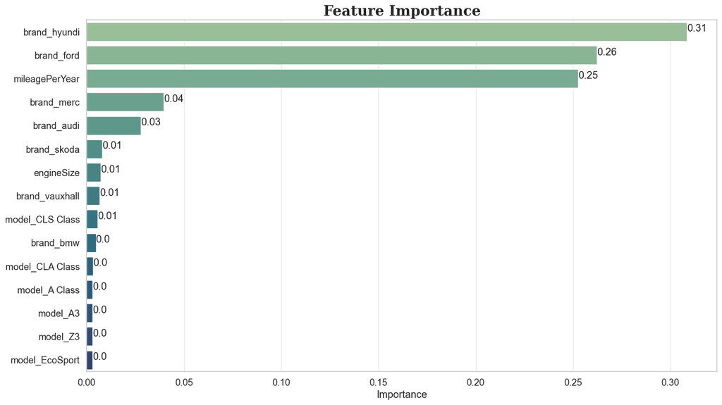

```python
fig, ax = plt.subplots(figsize=(16, 9))

# Only show top 10 features and bottom 10 features
features_df = features_df.head(15)

sns.barplot(
    data=features_df,
    x='Importance',
    y=features_df.index,
    ax=ax,
    palette='crest'
)

ax.set_title("Feature Importance", fontfamily='serif', fontweight='bold', fontsize=20)
# Set text labels
[ax.text(x=val, y=idx, s=round(val,2)) for idx, val in zip(np.arange(0, len(features_df)), features_df['Importance'])]

plt.show()
```

**Observations**:

## 5. Summary

With the model training complete, we can now save the model to disk

I have to use gzip to save the model in order to compress space otherwise it cannot be pushed. To Open the Model:

```
with gzip.open('../application/static/joblib_Model.gz', 'rb') as f:
    model = pickle.load(f)
```

```python
# Save the model to disk
import gzip

with gzip.open('../application/static/joblib_Model.gz', 'wb') as f:
    pickle.dump(tuned_rf, f, protocol=4)
```